# MetagenomicAssemblyFettsirte

Understanding the full genomic potential within a microbial community is key to comprehend the biological/functional abilities of this specific meta community. Virulence, Resistence aswell as specific functions/phenotypes are likely dependend on specific aquired features which might not be present in reference genomes.

Knowning the composition of microbial communities is the basis for understanding interactions therein. Interactions between organisms can quickly become very complex. Therefore understanding the general patterns in lower complexity assemblages should enable a crucial insight into all different microbial interactions. As most functional asseys rely on a well sequenced and annotated genome, genome assembly and annotation is key for downstream analysis. Sofar most analysis aiming at understand micbrobial compostion have used a targeted amplicon approach.

However there are well known limitations including biases introduced by copy-number variations (Klappenbach 2001), variability in amplification efficiency (Engelbrektson et al. 2010), inconsistencies when targeting different regions of this gene (Claesson et al. 2010), and problems with accurately and consistently delineating prokaryotic species(Gevers et al. 2005).

Therefor to truely understand the specific species and intra-species diversity shotgun whole genome sequencing of the metagenome should be considered. The most recent improvments in third generation sequencing enable sofar unprecedented oppurtunities to sequence entire metagenomes of low complexity communities.

Additonally to the taxonomic profiling whole metagenome sequencing has further advantages in the gene functional analysis (J. Qin et al. 2012,Forslund et al. (2013)) aswell as the genomic variation analysis (Sunagawa et al. 2013).

## cheese community literature

Cheese acounts for a low complexity microbial community consisting mainly of a few lactic acid bacteria. Sofar cheese community have been assesed mainly based on targeted amplicon sequencing (Ercolini 2013) which provides information restricted to the phylogenetic composition of the samples. Many milk fermenation products such as mozzarella cheese (Ercolini et al. 2012), Kazakhstan Cheese (J. Li et al. 2017), and Mexican Poro cheese (Aldrete-Tapia et al. 2014) but also very traditional indian fermented milk products(Nakibapher et al. 2018). However, studies based on targetd amplicon sequencing are limited to the identification of the microbial community to the genus and with longer SMRT seq to the species level. However, there is much more to learn from microbial community of fermented food products than just the mere species diversity and abundance. Intraspecific variation independent of the strain definition has been accounted for palette of different phenotypic effects. Most famous are pathogenecity (Karch et al. 2012), antibiotic resistance (ref),… In order to comprehend the full potential of the whee starter culture, the genomes have to be completely sequenced and assembled de novo for all microbial organism.

#### shotgun metagenomics of fermented foods

Sofar only few studies have done a shotgun metagenomic approach of food related microbial communities. - A 454 based study of Kimchi (Jung et al. 2011) - unmarinated and marinated broiler meat (Nieminen et al. 2012) - All-Food-Seq (AFS): A quantifiable screen for species in biological samples by deep DNA sequencing (Ripp et al. 2014) - dairy microbial genome catalog (Almeida et al. 2014): In order to overcome the shortcomings of short read sequencing for food metagenomics an extenisve dairy microbial genome catalog consisting of 142 bacterial draft genomes. A reference genome guided assembly potentially gives additional taxonomic resolution it will however not be able to identify function units or novel pathways within intraspecific diversity.

## advantages and difficulties of long read sequencing on solving metagenomes

Ongoing improvements of both Pacbio (RSII and Sequel) as well as Nanopore (Minion and Promethion) for increased read length, higher throughput and read quality have changed the field of whole genome sequencing. Assembling complete circularized genomes is becoming a standard. It is well known that for completely assembling a genome the sequencing reads need to span the longest intragenomic repeat region (Olson et al. 2017). For metagenomic assemblies the reads however not only have to span intragenomic repeats but also intergenomic repeats. An intergenomic repeat is a homological sequence between two or more co-occurring organism. These repeats are not generally of low complexity but can also be of low divergence and therefore are intrinsically indistinguishable. These repeats can be resolved by either spanning the repeat with long sequences to anchor within unique flanking regions or by increased sequencing quality whereby genomes can be discriminated solely based on subtle differences.

## Advantages of whole genome metagenomics in comparison to targeted amplicon sequencing of communities.

Sequencing the entire DNA potential within the environment of interest has multiple advantages. 1. No PCR biases due to different binding abilities of the primers to different sequences. 2. Better resolution to identifing higher order taxonomical differences. For exmaple in pinpointing strain level or resistence. Like antibiotic restistance. 3. ability to indentify core metagenomes if multiple treatments and multiple replicates. 4. possibility to identifiy treatment specific metagenomes 5. functional annotation of sequencing data and implications of genotype/genes on phenotype 6.Fundamental basis for all further ’omic analysis and functional analysis of specific environment. 7. Without complete genomes of the specific strains, studies are limited to the study of targeted genes or SNPs. Final ability to study large structural variation (relocations and horizontal gene transfer), which potentially have sofar unprecedented effects on the phenotype.

## Importance of exact species/strain assembly

The genetic differences within E.coli that cause a severe food poisening are very subtle and consist only of a handful of virulence factors such as Shiga toxin 2-encoding prophage (Karch et al. 2012). Therefore it is clinically of utter importance to identify the preciese genetic background.

## Discussion

Maybe the two Fettsirte match functionally (KEGG,GO) but not taxonomically.

#### Lactobacillus helveticus

Lactobacillus helveticus is well-known for its proteolytic activity, which is of importance in reducing the cheese bitterness (Griffiths and Tellez 2013).

#### thermophilus and Lactobacillus delbrueckii

Streptococcus thermophilus and Lactobacillus delbrueckii are known to be in tight association (S. Y. Yang et al. 2008). S. thermophilus actively supports L. delbrueckii growth by producing acing and dissolving oxygen to CO2 thereby creating the optimal anearobic conditions necessary for L. delrueckii. On the other hand. On the contrary L. delbrueckii stimulates S. thermophilus growth by the release of amino acids through proteolytic enzymatic activity (Aghababaie, Khanahmadi, and Beheshti 2015).

#### Conclusions

The relationship of the specific genotyp and the phenotype are in tight association. The study of the specific genotypes will be vital for future understanding and potential engineering of microbial communities. It will be critical to determine and record pivotal metainfomration of the specific community. Such metainformation should consist of quantitaive information such as sample origin, sampling time, pH, salinity, ripening degree, cheese type but also qualitative information such as taste or smell. These standards have to become common practice in every community based study.

## Our study setup

We have ran two Fettsirte on one Sequel run each. These Fettsirte originate from the Gruyere cheese production in Switzerland. One Fettsirte is called Cottens and has approxamatly 2 Mio. reads. the second Fettsirte is called LaPraz and has approxamatly 5 Mio. reads.

#### Set global options and bash shortcuts

```r
knitr::opts_chunk$set(fig.width=12, fig.height=8,warning=FALSE, message=FALSE)
```

## creat file shortcuts

Before starting all file and programm locations have to be filled out or check. These shortcut locations will be used throughout the code and therefor have to only be adjusted once.

However the fileShortucts.sh script location has to be changed with a search/replace throughout the scirpt if necessary!

```r
file=/home/bioinf/bioinf_archive/43_sovi_storage/Projects/Fettsirte/Run20171109/02_scripts/fileShortcuts.sh

##header
echo '#!/bin/bash' > $file
##locations
echo 'DATA_ROOT=/home/bioinf/bioinf_archive/43_sovi_storage/Projects/Fettsirte/Run20171109' >> $file
echo 'minimap2_root=/home/bioinf/extradrv/minimap2/minimap2' >> $file
echo 'miniasm_root=/home/bioinf/extradrv/miniasm' >> $file
echo 'SMRTLINK_ROOT=/home/bioinf/extradrv/opt/pacbio/smrtlink/userdata/jobs_root/000' >> $file
echo 'blast_root=/home/bioinf/extradrv/ncbi-blast-2.7.1+/bin' >> $file
echo 'blastdb=/home/bioinf/bioinf_archive/43_sovi_storage/blastArchive' >> $file
echo 'sprai_root=/home/bioinf/extradrv/sprai-0.9.9.23' >> $file
echo 'abruijn_root=/home/bioinf/extradrv/abruijn/ABruijn-master/bin' >> $file
echo 'circular_root=/home/bioinf/extradrv/identifyCircularContigs-master' >> $file
echo 'bbmap_root=/opt/Geneious/bundledPlugins/com.biomatters.plugins.bbtools.BBToolsPlugin/com/biomatters/plugins/bbtools/BBMap_37.25/bbmap/' >> $file
echo 'blob_root=/home/bioinf/extradrv/blobology' >> $file
echo 'QUAL_ROOT=/home/bioinf/apps/qualimap_v2.2.1/' >> $file
echo 'mpa_dir=/home/bioinf/extradrv/biobakery-metaphlan2-d8ab9ca4244c' >> $file
echo 'aditiBlastDB=/home/bioinf/bioinf_archive/30_vaad_storage/BLASTDB/nt_db' >> $file
echo 'mOTU_ROOT=/home/bioinf/extradrv' >> $file
echo 'metapha=/home/bioinf/extradrv/biobakery-metaphlan2-d8ab9ca4244c' >> $file
echo 'ngmlr_root=/home/bioinf/extradrv/ngmlr-0.2.6' >> $file
echo 'sniffles_root=/home/bioinf/extradrv/Sniffles-master/bin/sniffles-core-1.0.8' >> $file
echo 'flye_root=/home/bioinf/extradrv/Flye/bin/flye' >> $file
echo 'pacbio_root=/home/bioinf/extradrv/opt/pacbio/smrtlink/smrtcmds/bin' >> $file
echo 'mauve_root=/home/bioinf/extradrv/mauve_snapshot_2015-02-13/linux-x64/' >> $file
echo 'prokka_root=/home/bioinf/extradrv/prokka/bin/' >> $file
echo 'Illumina_raw=/home/bioinf/bioinf_data/32_scmi/ReportMiSeqDani0102/input' >> $file
echo 'rRNAdb=/home/bioinf/Downloads/sortmerna-2.1b/rRNA_databases/rfam5s_silva16s_silva23s_bac.fasta' >> $file
echo 'rRNAdbindex=/home/bioinf/bioinf_data/43_sovi/Projects/Metagenomics_pipeline/Model_data/e_coli/04_trial_04/SortmeRNAindex/rfam5s_silva16s_silva23s_bac.idx' >> $file
echo 'freebayes_root=/home/bioinf/extradrv/freebayes/bin' >> $file
echo 'bcftools_root=/home/bioinf/extradrv/bcftools' >> $file










echo 'ASSEMBLY_FLYE_POLISHED_FASTA=/home/bioinf/bioinf_archive/43_sovi_storage/Projects/Fettsirte/Run20171109/15_flye/assembly_cottens_min5000/SmrtLink_polished_reference/reference_cottens.fasta' >> $file

#echo 'timestamp() {date +"%T"}'>> $file
```

## File locations

```r
source /home/bioinf/bioinf_archive/43_sovi_storage/Projects/Fettsirte/Run20171109/02_scripts/fileShortcuts.sh

##rawData
rawData_cottens=$DATA_ROOT/01_SMRTlink_data/cottens/reads.fastq
rawData_lapraz=$DATA_ROOT/01_SMRTlink_data/lapraz/reads.fastq

##size selected rawData
min5000bp_cottens=$DATA_ROOT/01_SMRTlink_data/01_cottens_min5000bp/reads.fastq
min5000bp_lapraz=$DATA_ROOT/01_SMRTlink_data/01_lapraz_min5000bp/reads.fastq
```

## Sequencing stats

```r
.libPaths("/home/bioinf/bioinf_data/43_sovi/R/")

suppressPackageStartupMessages(library("ggplot2"))
suppressPackageStartupMessages(library("rjson"))
#suppressPackageStartupMessages(library("knitr"))
#source("https://bioconductor.org/biocLite.R")
#suppressPackageStartupMessages(library("Repitools"))
suppressPackageStartupMessages(library("curatedMetagenomicData"))
suppressPackageStartupMessages(library("fastqcr"))
suppressPackageStartupMessages(library("readr"))
suppressPackageStartupMessages(library("dplyr"))
#suppressPackageStartupMessages(library("MetaComp"))
suppressPackageStartupMessages(library("ggplot2"))
suppressPackageStartupMessages(library("gridExtra"))



source("/home/bioinf/bioinf_data/43_sovi/R_functions/R_functions/g_legend.R")

# biocLite("curatedMetagenomicData")
# biocLite("fastqcr")
```

## make Quality control of the raw reads

#### BamQc

```r
##------------
##Definitions
##------------
source /home/bioinf/bioinf_archive/43_sovi_storage/Projects/Fettsirte/Run20171109/02_scripts/fileShortcuts.sh
##------------
##bamqc for raw reads
##------------
for name in cottens lapraz
   do
    mkdir -p $DATA_ROOT/01_SMRTlink_data/${name}/bamqc
    $QUAL_ROOT/qualimap bamqc -bam /home/bioinf/bioinf_archive/32_scmi_storage/archivePacBio/fettsirte1_02112017/scratch/pacbio_tmp/tmpWL3QGn/1_8_La_praz_3_D02.tar.gz/m54073_171026_034928.subreads.bam -outdir $DATA_ROOT/01_SMRTlink_data/${name}/bamqc --java-mem-size=2G
   done
```

make FASTQC

```r
##----------
##fastqc
##----------
fastqc_cottens <- qc_read("/home/bioinf/bioinf_archive/43_sovi_storage/Projects/Fettsirte/Run20171109/01_SMRTlink_data/cottens/fastqc/reads_fastqc.zip")
fastqc_lapraz <- qc_read("/home/bioinf/bioinf_archive/43_sovi_storage/Projects/Fettsirte/Run20171109/01_SMRTlink_data/lapraz/fastqc/reads_fastqc.zip")

seq_length_cottens <- read_delim("~/bioinf_archive/43_sovi_storage/Projects/Fettsirte/Run20171109/01_SMRTlink_data/cottens/seq_length.ttxt", "\t", escape_double = FALSE, col_names = c("read","length"), trim_ws = TRUE)

seq_length_lapraz <- read_delim("~/bioinf_archive/43_sovi_storage/Projects/Fettsirte/Run20171109/01_SMRTlink_data/lapraz/seq_length.ttxt", "\t", escape_double = FALSE, col_names = c("read","length"), trim_ws = TRUE)

##reads longer than
for(i in c("cottens","lapraz")){
nam <- paste("readlength_distribution_",i,sep="")
nam_2 <- paste("fastqc_",i,sep="")
nam_3 <- paste("seq_length_",i,sep="")

ggplot(get(nam_3),aes(x=length))+geom_histogram(binwidth = 500)+theme_light()+labs(title=nam_3)

sizethreshold<- 7000
print(c("There are:",sum(get(nam_3)[,2]>sizethreshold),"reads larger than",sizethreshold,"for",i))
}

##reads range
for(i in c("cottens","lapraz")){
nam <- paste("readlength_distribution_",i,sep="")
nam_2 <- paste("fastqc_",i,sep="")
nam_3 <- paste("seq_length_",i,sep="")

print(c("For ",i,"the min read length is:",min(get(nam_3)[,2]),"and max: ",max(get(nam_3)[,2])))

}

##make a stats output


json_file <- "../04_HGAP4/20171114assembly_lapraz/stats/mapping_stats_hgap.json"
general_stats_1 <- fromJSON(file=json_file)

json_file <- "../04_HGAP4/20171114assembly_cottens//stats/mapping_stats_hgap.json"
general_stats_2 <- fromJSON(file=json_file)

##create table

total_seq_bases_1 <- round((general_stats_1$attributes[[4]]$value)/(general_stats_1$attributes[[2]]$value*100)*100)
total_seq_bases_2 <- round((general_stats_2$attributes[[4]]$value)/(general_stats_2$attributes[[2]]$value*100)*100)



stats_table <- data.frame("total Seq bases"=c(total_seq_bases_1,total_seq_bases_2),
                          "percent mapped bases"=c(general_stats_1$attributes[[1]]$value,general_stats_2$attributes[[1]]$value),
                          "number of subread"=c(general_stats_1$attributes[[3]]$value,general_stats_2$attributes[[3]]$value),
                          "number of subreads bases (realigned)"=c(general_stats_1$attributes[[3]]$value,general_stats_2$attributes[[3]]$value),
                          "Subread Length Mean"=c(general_stats_1$attributes[[5]]$value,general_stats_2$attributes[[5]]$value),
                          "Subread Length N50"=c(general_stats_1$attributes[[6]]$value,general_stats_2$attributes[[6]]$value),
                          "Subread Length Max"=c(general_stats_1$attributes[[8]]$value,general_stats_2$attributes[[8]]$value)
                          )
rownames(stats_table) <- c("lapraz","cottens")
knitr::kable(stats_table)
```

# Multifastqc of all raw data

In order to have an overview over the raw data, the min 5000bp reads and the preassembled reads we create in the following a common multifastqc report.

```r
source /home/bioinf/bioinf_archive/43_sovi_storage/Projects/Fettsirte/Run20171109/02_scripts/fileShortcuts.sh

mkdir -p $DATA_ROOT/01_SMRTlink_data/MultiQc/
multiqc  -f --title mulitQC_fasta --outdir $DATA_ROOT/01_SMRTlink_data/MultiQc/ \
        $DATA_ROOT/01_SMRTlink_data/cottens/fastqc \
        $DATA_ROOT/01_SMRTlink_data/lapraz/fastqc \
        $DATA_ROOT/01_SMRTlink_data/01_cottens_min5000bp/fastqc \
        $DATA_ROOT/01_SMRTlink_data/01_lapraz_min5000bp/fastqc \
        $DATA_ROOT/01_SMRTlink_data/cottens_ccs/fastqc \
        $DATA_ROOT/01_SMRTlink_data/lapraz_ccs/fastqc
```

# 1. Taxon profiling from metagenomic data

Knowning the organsims within a community is often the first and for many studies the most important information. For shotgun metagenome studies this is often done before assembling the sequencing data, as only the most abundant species can be de novo assembled (Driscoll et al. 2017). The key advantage of the metagenomic approach over a targeted amplicon approach is mainly the high resolution. A palette of different methods have enabled to profile strain level diversity from metagenomic data. However this approach is often limited to the thoroughness of the sequence database.

Apart from a phylogenetic survey of the microbial communities the shotgun metagenomic approach enables the de novo assembly of the dominant species which was sofar mainly restricted to cultureable species. Thereby enabling the analysis of structural variation, genomic linkage of functions to specific genes and organisms and building the necassary basis for further omics analysis of this microbial community. In future with studies including multiple replicates the theoretical understanding of microbial communities could change to a core metagenome approach idenpednent of specific organsims but rather on the basis of occuring genes or functions.

Further getting an idea of the metagenome size and genetic divergence is potentially crucial for the parametrisization of the assemblers.

## Obtions for species and strain profiling

1. Metaphlan2: enables the profiling based on the clade-specific-marker genes(genes computed from the constantly updated prokaryotic Refseqdatabase (Segata et al. 2013).
2. mOTU: based on universal, single-copy marker genes which provide prokaryotic species boundaries at higher resolution than 16SrRNA (Sunagawa et al. 2013). However does not work with Pacbio raw reads.

### Metaphlan2

Metaphlan2 is a tool based on the blastdb and specifically of uniq genes for each taxonomic classes therein. However this method was orignally developed for the usage with Illumina short read technology. In the following we aim to test how well the taxonomic classification/profiling works for raw long read sequencing data.

For the taxonmic profiling we use the preassemble reads. These reads are both longer aswell as error corrected which should increase the power of the results.

```r
source /home/bioinf/bioinf_archive/43_sovi_storage/Projects/Fettsirte/Run20171109/02_scripts/fileShortcuts.sh

##----------------
##metaphlan Usage for raw reads
##----------------

for name in cottens lapraz
   do
    mkdir -p $DATA_ROOT/06_metaphlan/${name}_raw/{bowtie2ouput,metaphlan_profile}/
    rm $DATA_ROOT/06_metaphlan/${name}_raw/bowtie2ouput/metagenome_${name}_raw.bowtie2.bz2
    $mpa_dir/metaphlan2.py $DATA_ROOT/01_SMRTlink_data/${name}/reads_${name}_raw.fastq --bowtie2out $DATA_ROOT/06_metaphlan/${name}_raw/bowtie2ouput/metagenome_${name}_raw.bowtie2.bz2 --nproc 12 --input_type fastq > $DATA_ROOT/06_metaphlan/${name}_raw/metaphlan_profile/profiled_metagenome_${name}_raw.txt
   done

##----------------
##metaphlan Usage for preassembled reads
##----------------

for name in cottens lapraz
   do
    mkdir -p $DATA_ROOT/06_metaphlan/${name}_preassembled/{bowtie2ouput,metaphlan_profile}/
    rm $DATA_ROOT/06_metaphlan/${name}_preassembled/bowtie2ouput/metagenome_${name}_preassembled.bowtie2.bz2
    $mpa_dir/metaphlan2.py $DATA_ROOT/01_SMRTlink_data/${name}/preassembled_reads/preads4falcon_${name}.fasta --bowtie2out $DATA_ROOT/06_metaphlan/${name}_preassembled/bowtie2ouput/metagenome_${name}_preassembled.bowtie2.bz2 --nproc 12 --input_type fasta > $DATA_ROOT/06_metaphlan/${name}_preassembled/metaphlan_profile/profiled_metagenome_${name}_preassembled.txt
   done

##----------------
##metaphlan Usage Illumina cottens
##----------------

mkdir -p $DATA_ROOT/01_SMRTlink_data/cottensIllumina
zcat /home/bioinf/bioinf_data/32_scmi/ReportMiSeqDani0102/input/P1761-3752-2-2_S6_L001_R1_001.fastq.gz /home/bioinf/bioinf_data/32_scmi/ReportMiSeqDani0102/input/P1761-3752-2_S3_L001_R1_001.fastq.gz /home/bioinf/bioinf_data/32_scmi/ReportMiSeqDani0102/input/P1761-3752-2-2_S6_L001_R2_001.fastq.gz /home/bioinf/bioinf_data/32_scmi/ReportMiSeqDani0102/input/P1761-3752-2_S3_L001_R2_001.fastq.gz > $DATA_ROOT/01_SMRTlink_data/cottensIllumina/all_Illumina_RawReads_cottens_cat.fastq


name=cottens
mkdir -p $DATA_ROOT/06_metaphlan/${name}_Illumina/{bowtie2ouput,metaphlan_profile}/
    rm $DATA_ROOT/06_metaphlan/${name}_Illumina/bowtie2ouput/metagenome_${name}_rawIllumina.bowtie2.bz2

    $mpa_dir/metaphlan2.py $DATA_ROOT/01_SMRTlink_data/cottensIllumina/all_Illumina_RawReads_cottens_cat.fastq --input_type fastq --bowtie2out $DATA_ROOT/06_metaphlan/${name}_Illumina/bowtie2ouput/metagenome_${name}_rawIllumina.bowtie2.bz2 --nproc 12 > $DATA_ROOT/06_metaphlan/${name}_Illumina/metaphlan_profile/profiled_metagenome_${name}_rawIllumina.txt



###--------------
##Lapraz
###--------------
mkdir -p $DATA_ROOT/01_SMRTlink_data/laprazIllumina
zcat /home/bioinf/bioinf_data/32_scmi/ReportMiSeqDani0102/input/P1761-3752-1-2_S12_L001_R1_001.fastq.gz /home/bioinf/bioinf_data/32_scmi/ReportMiSeqDani0102/input/P1761-3752-1_S9_L001_R1_001.fastq.gz /home/bioinf/bioinf_data/32_scmi/ReportMiSeqDani0102/input/P1761-3752-1-2_S12_L001_R2_001.fastq.gz /home/bioinf/bioinf_data/32_scmi/ReportMiSeqDani0102/input/P1761-3752-1_S9_L001_R2_001.fastq.gz > $DATA_ROOT/01_SMRTlink_data/laprazIllumina/all_Illumina_RawReads_lapraz_cat.fastq


name=lapraz
mkdir -p $DATA_ROOT/06_metaphlan/${name}_Illumina/{bowtie2ouput,metaphlan_profile}/
    rm $DATA_ROOT/06_metaphlan/${name}_Illumina/bowtie2ouput/metagenome_${name}_rawIllumina.bowtie2.bz2

    $mpa_dir/metaphlan2.py $DATA_ROOT/01_SMRTlink_data/laprazIllumina/all_Illumina_RawReads_lapraz_cat.fastq --input_type fastq --bowtie2out $DATA_ROOT/06_metaphlan/${name}_Illumina/bowtie2ouput/metagenome_${name}_rawIllumina.bowtie2.bz2 --nproc 12 > $DATA_ROOT/06_metaphlan/${name}_Illumina/metaphlan_profile/profiled_metagenome_${name}_rawIllumina.txt
```

```r
install.packages("Metacomb")

metaphlan_cottens <- load_metaphlan_assignment("/home/bioinf/bioinf_archive/43_sovi_storage/Projects/Fettsirte/Run20171109/06_metaphlan/cottens_preassembled/metaphlan_profile/profiled_metagenome_cottens_preassembled.txt")

metaphlan_lapraz <- load_metaphlan_assignment("/home/bioinf/bioinf_archive/43_sovi_storage/Projects/Fettsirte/Run20171109/06_metaphlan/lapraz_preassembled/metaphlan_profile/profiled_metagenome_lapraz_preassembled.txt")
```

## PanPhlAn

PanPhlAn is a very recent species/strain profiler for shotgun metagenomic data.

In a first step, they have a good manual how to batch download a bunch of genomes from NCBI.

## sortmeRNA

```r
source /home/bioinf/bioinf_archive/43_sovi_storage/Projects/Fettsirte/Run20171109/02_scripts/fileShortcuts.sh

##----------------
##sortmeRNA of raw pacbio data
##----------------
for name in cottens lapraz
   do
    SECONDS=0
    mkdir -p $DATA_ROOT/21_sortmeRNA/Pacbio_raw_${name}/
    sortmerna --ref $rRNAdb,$rRNAdbindex \
    --reads $DATA_ROOT/01_SMRTlink_data/${name}/reads_${name}_raw.fastq --log -v \
     --fastx --aligned $DATA_ROOT/21_sortmeRNA/Pacbio_raw_${name}/raw_pacbio_${name}_rRNA_aligned_rRNA_reads
    echo "RUNTIME (h:min:s)= $(($SECONDS / 3600)):$((($SECONDS / 60) % 60)):$(($SECONDS % 60))"
    echo END = `date +"%Y-%m-%d %H:%M:%S"`
   done

##----------------
##sortmeRNA of raw Illumina data
##----------------

##--------------first only for cottens----------------------------

#for name in cottens lapraz
#   do
   name=cottens
    SECONDS=0
    mkdir -p $DATA_ROOT/21_sortmeRNA/Illumina_raw_${name}/
    sortmerna --ref $rRNAdb,$rRNAdbindex \
    --reads $DATA_ROOT/01_SMRTlink_data/cottensIllumina/all_Illumina_RawReads_cottens_cat.fastq --log -v \
     --fastx --aligned $DATA_ROOT/21_sortmeRNA/Pacbio_raw_${name}/raw_illumina_${name}_rRNA_aligned_rRNA_reads
    echo "RUNTIME (h:min:s)= $(($SECONDS / 3600)):$((($SECONDS / 60) % 60)):$(($SECONDS % 60))"
    echo END = `date +"%Y-%m-%d %H:%M:%S"`
#   done
```

## mOTU taxonomic annotation

In order to test the Metaphlan output we use a second well known taxonomic profiler for metagenomic datasets. However mOTU does not work with Pacbio data. mOTU was made only for short next generation sequencing technologies, specifically for Illumina, Ion Torrent or 454.

## blast raw reads against the entire ncbi database

Blasting all RawReads against the ncbi database should give the most comprehensive taxonomic analysis of the present data. This is however a very time consuming step. Especially as the we need to reduce the wordsize of the blast to 12 in order to account for the high error rate of the pacbio RawReads.

```r
source /home/bioinf/bioinf_archive/43_sovi_storage/Projects/Fettsirte/Run20171109/02_scripts/fileShortcuts.sh

##----------------
##fastq2fasta
##----------------
for name in cottens lapraz
   do
    SECONDS=0
    sed -n '1~4s/^@/>/p;2~4p' $DATA_ROOT/01_SMRTlink_data/${name}/reads_${name}_raw.fastq  > $DATA_ROOT/01_SMRTlink_data/${name}/reads_${name}_raw.fasta
    echo "RUNTIME (h:min:s)= $(($SECONDS / 3600)):$((($SECONDS / 60) % 60)):$(($SECONDS % 60))"
    echo END = `date +"%Y-%m-%d %H:%M:%S"`
   done
##----------------
##blast
##----------------

for name in cottens lapraz
   do
    mkdir -p $DATA_ROOT/01_SMRTlink_data/${name}/blast
    SECONDS=0
    $blast_root/blastn -num_threads 16 -max_hsps 1 -max_target_seqs 1 -task megablast -show_gis -query $DATA_ROOT/01_SMRTlink_data/${name}/reads_${name}_raw.fasta -outfmt "6 qseqid sseqid pident length mismatch gapopen qstart qend sstart send evalue bitscore stitle slen" -db $aditiBlastDB/nt -out $DATA_ROOT/01_SMRTlink_data/${name}/blast/${name}_blast_allRawReads.txt -evalue 0.01 -word_size 12
    echo "RUNTIME (h:min:s)= $(($SECONDS / 3600)):$((($SECONDS / 60) % 60)):$(($SECONDS % 60))"
    echo END $name = `date +"%Y-%m-%d %H:%M:%S"`
  done

##----------------
##blast batch run
##----------------
date=20170124

name=cottens
    #mkdir -p $DATA_ROOT/01_SMRTlink_data/${name}/blast
    #SECONDS=0

    LastLine=$(tail -1 $DATA_ROOT/01_SMRTlink_data/${name}/blast/${name}_blast_allRawReads_subset_${date}.txt|cut -f 1)
    LineTrue=$(grep "$LastLine" -n $DATA_ROOT/01_SMRTlink_data/${name}/reads_${name}_raw.fasta|awk -F":" '{print 758929-$1}')
    date=20170202
    tail -$LineTrue $DATA_ROOT/01_SMRTlink_data/${name}/reads_${name}_raw.fasta > $DATA_ROOT/01_SMRTlink_data/${name}/reads_${name}_raw_subset_${date}.fasta

    $blast_root/blastn -num_threads 16 -max_hsps 1 -max_target_seqs 1 -task megablast -show_gis -query $DATA_ROOT/01_SMRTlink_data/${name}/reads_${name}_raw_subset_${date}.fasta -outfmt "6 qseqid sseqid pident length mismatch gapopen qstart qend sstart send evalue bitscore stitle slen" -db $aditiBlastDB/nt -out $DATA_ROOT/01_SMRTlink_data/${name}/blast/${name}_blast_allRawReads_subset_${date}.txt -evalue 0.01 -word_size 12
    echo "RUNTIME (h:min:s)= $(($SECONDS / 3600)):$((($SECONDS / 60) % 60)):$(($SECONDS % 60))"
    echo END $name = `date +"%Y-%m-%d %H:%M:%S"`


##----------------
##blast batch run reverse (michis machine)
##----------------

#tail -367062 $DATA_ROOT/01_SMRTlink_data/${name}/reads_${name}_raw.fasta > $DATA_ROOT/01_SMRTlink_data/${name}/reads_${name}_raw_master_michi_${date}.fasta

cp -r /home/bioinf/bioinf_archive/30_vaad_storage/BLASTDB/nt_db  /home/bioinf/bioinf_archive/30_vaad_storage/BLASTDB/nt_db_duplicate
blast_root_michi=/home/bioinf/Software/blast_2_7_1/ncbi-blast-2.7.1+/bin
DATA_ROOT=/home/bioinf/bioinf_archive/43_sovi_storage/Projects/Fettsirte/Run20171109
aditiBlastDB=/home/bioinf/bioinf_archive/30_vaad_storage/BLASTDB/nt_db_duplicate/nt_db4

date_old=20170125
date=20170202
name=cottens
    #mkdir -p $DATA_ROOT/01_SMRTlink_data/${name}/blast
    #SECONDS=0

    LastLine=$(tail -1 $DATA_ROOT/01_SMRTlink_data/${name}/blast/${name}_blast_allRawReads_reverse_subset_${date_old}.txt|cut -f 1)
    LineTrue=$(grep "$LastLine" -n $DATA_ROOT/01_SMRTlink_data/${name}/reads_${name}_raw_master_michi_20170125.fasta|awk -F":" '{print 367062-$1}')
    tail -$LineTrue $DATA_ROOT/01_SMRTlink_data/${name}/reads_${name}_raw_master_michi_20170125.fasta > $DATA_ROOT/01_SMRTlink_data/${name}/reads_${name}_raw_subset_michi_${date}.fasta

     $blast_root_michi/blastn -num_threads 16 -max_hsps 1 -max_target_seqs 1 -task megablast -show_gis -query $DATA_ROOT/01_SMRTlink_data/${name}/reads_${name}_raw_subset_michi_${date}.fasta -outfmt "6 qseqid sseqid pident length mismatch gapopen qstart qend sstart send evalue bitscore stitle slen" -db $aditiBlastDB/nt -out $DATA_ROOT/01_SMRTlink_data/${name}/blast/${name}_blast_allRawReads_reverse_subset_${date}.txt -evalue 0.01 -word_size 12
    #echo "RUNTIME (h:min:s)= $(($SECONDS / 3600)):$((($SECONDS / 60) % 60)):$(($SECONDS % 60))"
    #echo END $name = `date +"%Y-%m-%d %H:%M:%S"`
```

# Assemblies

The subreads are then used to assemble the genomes. In this point lies the major advantage of long reads. Long reads enable the spanning of repeat regions. In general long read assemblers consist of a Overlap Layout Consensus (OLC) algorithm.

In the following we try different assemblers.

## HGAP4

HGAP4 is the pacbio assembler implemented in SMRTlink 5.0. In the prelimary analysis based on the three Lactobacillus helveticus strains HGAP4 showed the best performance (precision and recall) for metagenome data. the HGAP4 assembly was run on default with an expected overall genome size of 10Mb. This was done in the SMRTlink GUI.

```r
source /home/bioinf/bioinf_archive/43_sovi_storage/Projects/Fettsirte/Run20171109/02_scripts/fileShortcuts.sh

###==========================
##check circularity
###==========================
for name in cottens lapraz
  do
    mkdir -p $DATA_ROOT/04_HGAP4/20171114assembly_${name}/fasta/multifasta
    $sprai_root/check_circularity.pl $DATA_ROOT/04_HGAP4/20171114assembly_${name}/fasta/assembly.fasta $DATA_ROOT/04_HGAP4/20171114assembly_${name}/fasta/multifasta --force > $DATA_ROOT/04_HGAP4/20171114assembly_${name}/fasta/cirularity.txt
  done
```

## flye

Flye is the updated version of the Abruijn assembler.It is originally made to optimise repeat rich genome assemblies. However as with any non-pacbio based assembler (HGap) it can not handle the quality score and therefor polishing of the reads has to be done with quiver or arrow The flye assembler creates a contigs.fasta and also an additional extended scaffolds.fasta file where it stitches together uncertain contigs. We create for both wheey cultueres two assemblies. 1. Starting the assembly with all raw subreads without quality nor length cutoff. 2. Starting the assembly with only raw subreads > 5000bp

```r
##---------
##directories
##---------
##source /home/bioinf/bioinf_archive/43_sovi_storage/Projects/Fettsirte/Run20171109/02_scripts/fileShortcuts.sh

##michis directories
flye_root=/home/bioinf/Software/Flye_2_31/Flye/bin/flye
blastn_root=blastn
minimap2_root=/home/bioinf/Software/minimap2Dec06/minimap2
DATA_ROOT=/home/bioinf/bioinf_archive/43_sovi_storage/Projects/Fettsirte/Run20171109
aditiBlastDB=/home/bioinf/bioinf_archive/30_vaad_storage/BLASTDB/nt_db/
##---------------
##creat flye directories
##---------------
for name in cottens lapraz
   do
    mkdir -p $DATA_ROOT/15_flye/{assembly_${name}_raw,assembly_${name}_min5000}/{quast,fasta,blast,rawReads2assembly_minimap2}
   done

##---------------
##create min5000bp reads
##---------------
for name in cottens lapraz
   do
    prinseq-lite.pl -fastq $DATA_ROOT/01_SMRTlink_data/${name}/reads_${name}_raw.fastq -min_len 5000 -out_good $DATA_ROOT/01_SMRTlink_data/${name}/reads_${name}_min5000bp -out_bad null -out_format 4
   done



##---------------
##flye assembly with rawReads
##---------------
size=5m
for name in cottens lapraz
  do
    $flye_root -t 25 --pacbio-raw $DATA_ROOT/01_SMRTlink_data/${name}/reads_${name}_raw.fastq --out-dir $DATA_ROOT/15_flye/assembly_${name}_raw/fasta --genome-size ${size} -m 5000 -i 3
    size=7m
  done

##---------------
##flye assembly with min5000bp reads
##---------------
size=5m
for name in cottens lapraz
  do
    $flye_root -t 25 --pacbio-raw $DATA_ROOT/01_SMRTlink_data/${name}/reads_${name}_min5000bp.fastq --out-dir $DATA_ROOT/15_flye/assembly_${name}_min5000/fasta --genome-size ${size} -m 5000 -i 3
    size=7m
  done
```

#### Minimap2 mapping of raw reads to the assemblies

We first need to mapped the raw reads or in general the reads which we want to use for polishing back to the reference genome proberly polish the assembled contigs. Pacbio offers a own aligner for this step. The PBAligner is describe [here](https://github.com/ben-lerch/Resequencing-3.0). This Pacbio aligner is not very well known. However it is necessary as it can incorporate the pulse width quality score into the alignment.

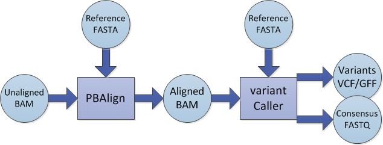

```r
source /home/bioinf/bioinf_archive/43_sovi_storage/Projects/Fettsirte/Run20171109/02_scripts/fileShortcuts.sh
##-------
##rawRead PBAlign to rawRead Scaffolds assembly
##-------

##cottens
RawBamSubreadscottens=/home/bioinf/bioinf_archive/32_scmi_storage/archivePacBio/fettsirte1_02112017/scratch/pacbio_tmp/tmpWL3QGn/2_7_Cottens_4_E02.tar.gz/m54073_171026_135911.subreads.bam
for name in cottens lapraz
   do
      mkdir -p $DATA_ROOT/15_flye/assembly_${name}_raw/rawReads2assembly_PBAlign
  $pacbio_root/pbalign --nproc 12 --concordant --hitPolicy randombest --minAccuracy 70 --minLength 50 --algorithmOptions "--minMatch 12 --bestn 10 --minPctSimilarity 70.0 --refineConcordantAlignments" \
      --unaligned $DATA_ROOT/15_flye/assembly_${name}_raw/rawReads2assembly_PBAlign/raw_${name}_PBAaligned_Scaffolds_woConsensu_unaligned.bam \
      ${RawBamSubreadscottens} \
      $DATA_ROOT/15_flye/assembly_${name}_raw/fasta/scaffolds.fasta \
      $DATA_ROOT/15_flye/assembly_${name}_raw/rawReads2assembly_PBAlign/raw_${name}_PBAaligned_Scaffolds_woConsensu.bam


      ##lapraz
      RawBamSubreadscottens=/home/bioinf/bioinf_archive/32_scmi_storage/archivePacBio/fettsirte1_02112017/scratch/pacbio_tmp/tmpWL3QGn/1_8_La_praz_3_D02.tar.gz/m54073_171026_034928.subreads.bam
   done



##-------
##rawRead PBAlign to min5000 Scaffolds assembly
##-------

##cottens
RawBamSubreadscottens=/home/bioinf/bioinf_archive/32_scmi_storage/archivePacBio/fettsirte1_02112017/scratch/pacbio_tmp/tmpWL3QGn/2_7_Cottens_4_E02.tar.gz/m54073_171026_135911.subreads.bam
for name in cottens lapraz
   do
      mkdir -p $DATA_ROOT/15_flye/assembly_${name}_min5000/rawReads2assembly_PBAlign
  $pacbio_root/pbalign --nproc 12 --concordant --hitPolicy randombest --minAccuracy 70 --minLength 50 --algorithmOptions "--minMatch 12 --bestn 10 --minPctSimilarity 70.0 --refineConcordantAlignments" \
      --unaligned $DATA_ROOT/15_flye/assembly_${name}_min5000/rawReads2assembly_PBAlign/raw_${name}_PBAaligned_Scaffolds_woConsensu_unaligned.bam \
      ${RawBamSubreadscottens} \
      $DATA_ROOT/15_flye/assembly_${name}_min5000/fasta/scaffolds.fasta \
      $DATA_ROOT/15_flye/assembly_${name}_min5000/rawReads2assembly_PBAlign/raw_${name}_PBAaligned_Scaffolds_woConsensu.bam




      ##lapraz
      RawBamSubreadscottens=/home/bioinf/bioinf_archive/32_scmi_storage/archivePacBio/fettsirte1_02112017/scratch/pacbio_tmp/tmpWL3QGn/1_8_La_praz_3_D02.tar.gz/m54073_171026_034928.subreads.bam


   done
```

## Polishing with SmrtLink resequencing

After the Flye assembly the scaffolds need to be polished with the Pacbio resquencing pipeline implemented within SmrtLink. This has to be done as the fastq files do not actually contain per base quality values. The original unmapped bam file however has certain metadata which is internally used for quality assessement.

```r
source /home/bioinf/bioinf_archive/43_sovi_storage/Projects/Fettsirte/Run20171109/02_scripts/fileShortcuts.sh

##-------
##rawRead Consensuspolishing of rawReads Scaffolds assembly (default)
##-------


for name in cottens lapraz
   do
    mkdir -p $DATA_ROOT/15_flye/assembly_${name}_raw/SmrtLink_polished_reference_arrow/assembly/

     samtools faidx $DATA_ROOT/15_flye/assembly_${name}_raw/fasta/scaffolds.fasta

    $pacbio_root/variantCaller --algorithm arrow --minConfidence 40 --minCoverage 5 --numWorkers 5 \
      -o $DATA_ROOT/15_flye/assembly_${name}_raw/SmrtLink_polished_reference_arrow/assembly/reference_${name}.fasta \
      -o $DATA_ROOT/15_flye/assembly_${name}_raw/SmrtLink_polished_reference_arrow/assembly/reference_${name}.fastq.gz \
      -o $DATA_ROOT/15_flye/assembly_${name}_raw/SmrtLink_polished_reference_arrow/assembly/reference_${name}_variants.vcf \
      -r $DATA_ROOT/15_flye/assembly_${name}_raw/fasta/scaffolds.fasta \
      $DATA_ROOT/15_flye/assembly_${name}_raw/rawReads2assembly_PBAlign/raw_${name}_PBAaligned_Scaffolds_woConsensu.bam

    done
##-------
##rawRead Consensuspolishing of min5000 Scaffolds assembly (default)
##-------


for name in cottens lapraz
   do
    mkdir -p $DATA_ROOT/15_flye/assembly_${name}_min5000/SmrtLink_polished_reference_arrow/assembly/

    samtools faidx $DATA_ROOT/15_flye/assembly_${name}_min5000/fasta/scaffolds.fasta

    $pacbio_root/variantCaller --algorithm arrow --minConfidence 40 --minCoverage 5 --numWorkers 5 \
      -o $DATA_ROOT/15_flye/assembly_${name}_min5000/SmrtLink_polished_reference_arrow/assembly/reference_${name}.fasta \
      -o $DATA_ROOT/15_flye/assembly_${name}_min5000/SmrtLink_polished_reference_arrow/assembly/reference_${name}.fastq.gz \
      -o $DATA_ROOT/15_flye/assembly_${name}_min5000/SmrtLink_polished_reference_arrow/assembly/reference_${name}_variants.vcf \
      -r $DATA_ROOT/15_flye/assembly_${name}_min5000/fasta/scaffolds.fasta \
      $DATA_ROOT/15_flye/assembly_${name}_min5000/rawReads2assembly_PBAlign/raw_${name}_PBAaligned_Scaffolds_woConsensu.bam

    done
```

#### Mapp Illumina Miseq reads to Pacbio assembly

We have ran a MiSeq run for the two whee cultures (cottens and Lapraz). The reads are 300bp PE. In the following we map the raw reads to the pacbio sequenced flye assembled genomes.

```r
source /home/bioinf/bioinf_archive/43_sovi_storage/Projects/Fettsirte/Run20171109/02_scripts/fileShortcuts.sh

###--------------
##Cottens
###--------------
name=cottens
mkdir -p $DATA_ROOT/15_flye/assembly_${name}_min5000/SmrtLink_polished_reference_arrow/raw_IlluminaMapped_true/bamqc
#bwa index $DATA_ROOT/15_flye/assembly_${name}_min5000/SmrtLink_polished_reference_arrow/assembly/reference_${name}.fasta
bwa mem $DATA_ROOT/15_flye/assembly_${name}_min5000/SmrtLink_polished_reference_arrow/assembly/reference_${name}.fasta '<zcat /home/bioinf/bioinf_archive/40_MiSeq_storage/do_not_touch/180129_M02824_0034_000000000-BK2J9/Data/Intensities/BaseCalls/P1761-3752-2_S3_L001_R1_001.fastq.gz /home/bioinf/bioinf_archive/40_MiSeq_storage/do_not_touch/180129_M02824_0034_000000000-BK2J9/Data/Intensities/BaseCalls/P1761-3752-2-2_S6_L001_R1_001.fastq.gz' '<zcat /home/bioinf/bioinf_archive/40_MiSeq_storage/do_not_touch/180129_M02824_0034_000000000-BK2J9/Data/Intensities/BaseCalls/P1761-3752-2_S3_L001_R2_001.fastq.gz /home/bioinf/bioinf_archive/40_MiSeq_storage/do_not_touch/180129_M02824_0034_000000000-BK2J9/Data/Intensities/BaseCalls/P1761-3752-2-2_S6_L001_R2_001.fastq.gz' -t 14 |samtools sort -@8 -O BAM -o $DATA_ROOT/15_flye/assembly_${name}_min5000/SmrtLink_polished_reference_arrow/raw_IlluminaMapped_true/rawIllumina_${name}_bwamem_Scaffolds_sorted.bam - | tee $DATA_ROOT/15_flye/assembly_${name}_min5000/SmrtLink_polished_reference_arrow/raw_IlluminaMapped_true/rawIllumina_${name}_bwamem_Scaffolds_sorted.log

      $QUAL_ROOT/qualimap bamqc -bam $DATA_ROOT/15_flye/assembly_${name}_min5000/SmrtLink_polished_reference_arrow/raw_IlluminaMapped_true/rawIllumina_${name}_bwamem_Scaffolds_sorted.bam -outdir $DATA_ROOT/15_flye/assembly_${name}_min5000/SmrtLink_polished_reference_arrow/raw_IlluminaMapped_true/bamqc --java-mem-size=2G

samtools index $DATA_ROOT/15_flye/assembly_${name}_min5000/SmrtLink_polished_reference_arrow/raw_IlluminaMapped_true/rawIllumina_${name}_bwamem_Scaffolds_sorted.bam

###--------------
##Lapraz
###--------------
name=lapraz
mkdir -p $DATA_ROOT/15_flye/assembly_${name}_min5000/SmrtLink_polished_reference_arrow/raw_IlluminaMapped_true/bamqc
bwa index $DATA_ROOT/15_flye/assembly_${name}_min5000/SmrtLink_polished_reference_arrow/assembly/reference_${name}.fasta
bwa mem $DATA_ROOT/15_flye/assembly_${name}_min5000/SmrtLink_polished_reference_arrow/assembly/reference_${name}.fasta '<zcat /home/bioinf/bioinf_archive/40_MiSeq_storage/do_not_touch/180129_M02824_0034_000000000-BK2J9/Data/Intensities/BaseCalls/P1761-3752-1_S9_L001_R1_001.fastq.gz /home/bioinf/bioinf_archive/40_MiSeq_storage/do_not_touch/180129_M02824_0034_000000000-BK2J9/Data/Intensities/BaseCalls/P1761-3752-1-2_S12_L001_R1_001.fastq.gz' '<zcat /home/bioinf/bioinf_archive/40_MiSeq_storage/do_not_touch/180129_M02824_0034_000000000-BK2J9/Data/Intensities/BaseCalls/P1761-3752-1_S9_L001_R2_001.fastq.gz /home/bioinf/bioinf_archive/40_MiSeq_storage/do_not_touch/180129_M02824_0034_000000000-BK2J9/Data/Intensities/BaseCalls/P1761-3752-1-2_S12_L001_R2_001.fastq.gz' -t 14 |samtools sort -@8 -O BAM -o $DATA_ROOT/15_flye/assembly_${name}_min5000/SmrtLink_polished_reference_arrow/raw_IlluminaMapped_true/rawIllumina_${name}_bwamem_Scaffolds_sorted.bam - | tee $DATA_ROOT/15_flye/assembly_${name}_min5000/SmrtLink_polished_reference_arrow/raw_IlluminaMapped_true/rawIllumina_${name}_bwamem_Scaffolds_sorted.log

      $QUAL_ROOT/qualimap bamqc -bam $DATA_ROOT/15_flye/assembly_${name}_min5000/SmrtLink_polished_reference_arrow/raw_IlluminaMapped_true/rawIllumina_${name}_bwamem_Scaffolds_sorted.bam -outdir $DATA_ROOT/15_flye/assembly_${name}_min5000/SmrtLink_polished_reference_arrow/raw_IlluminaMapped_true/bamqc --java-mem-size=2G

samtools index $DATA_ROOT/15_flye/assembly_${name}_min5000/SmrtLink_polished_reference_arrow/raw_IlluminaMapped_true/rawIllumina_${name}_bwamem_Scaffolds_sorted.bam
```

#### freebayes polishing

In the following we polish the pacbio assembled and arrow polished genome with the Illumina Miseq data. This workflow goes as following: 1. Variant calling based on pacbio genome and Illumina reads with freebayes. 2. Integrating the called variants with bcftools

```r
source /home/bioinf/bioinf_archive/43_sovi_storage/Projects/Fettsirte/Run20171109/02_scripts/fileShortcuts.sh

##-------
##freebayes variant calling with Illumina data onto Pacbio polished genome
##-------

for name in cottens lapraz
   do
    SECONDS=0
    mkdir -p $DATA_ROOT/15_flye/assembly_${name}_min5000/SmrtLink_polished_reference_arrow/freebayes_illumina_polished/freebayesPolishedAssembly

    $freebayes_root/freebayes -F 0.5 --min-coverage 8 -p 1 -f \
      $DATA_ROOT/15_flye/assembly_${name}_min5000/SmrtLink_polished_reference_arrow/assembly/reference_${name}.fasta \
      $DATA_ROOT/15_flye/assembly_${name}_min5000/SmrtLink_polished_reference_arrow/raw_IlluminaMapped_true/rawIllumina_${name}_bwamem_Scaffolds_sorted.bam > \
      $DATA_ROOT/15_flye/assembly_${name}_min5000/SmrtLink_polished_reference_arrow/freebayes_illumina_polished/freebayesPolishedAssembly/variantCallsfreebayes.vcf
    echo "RUNTIME (h:min:s)= $(($SECONDS / 3600)):$((($SECONDS / 60) % 60)):$(($SECONDS % 60))"
    echo END = `date +"%Y-%m-%d %H:%M:%S"`
  done


##-------
##bcftools variant integration of Illumina data into Pacbio polished genome
##-------

for name in cottens lapraz
   do
    SECONDS=0
    bgzip -c $DATA_ROOT/15_flye/assembly_${name}_min5000/SmrtLink_polished_reference_arrow/freebayes_illumina_polished/freebayesPolishedAssembly/variantCallsfreebayes.vcf > \
      $DATA_ROOT/15_flye/assembly_${name}_min5000/SmrtLink_polished_reference_arrow/freebayes_illumina_polished/freebayesPolishedAssembly/variantCallsfreebayes.vcf.gz

    tabix -p vcf $DATA_ROOT/15_flye/assembly_${name}_min5000/SmrtLink_polished_reference_arrow/freebayes_illumina_polished/freebayesPolishedAssembly/variantCallsfreebayes.vcf.gz

    $bcftools_root/bcftools consensus -f $DATA_ROOT/15_flye/assembly_${name}_min5000/SmrtLink_polished_reference_arrow/assembly/reference_${name}.fasta \
      -o $DATA_ROOT/15_flye/assembly_${name}_min5000/SmrtLink_polished_reference_arrow/freebayes_illumina_polished/freebayesPolishedAssembly/polished_${name}_polishedIllumina.fa $DATA_ROOT/15_flye/assembly_${name}_min5000/SmrtLink_polished_reference_arrow/freebayes_illumina_polished/freebayesPolishedAssembly/variantCallsfreebayes.vcf.gz
    echo "RUNTIME (h:min:s)= $(($SECONDS / 3600)):$((($SECONDS / 60) % 60)):$(($SECONDS % 60))"
    echo END = `date +"%Y-%m-%d %H:%M:%S"`
   done
```

#### Circlator

Use Circlator to close the genomes and close the residual gap in the Streptococcus genome.

```r
source /home/bioinf/bioinf_archive/43_sovi_storage/Projects/Fettsirte/Run20171109/02_scripts/fileShortcuts.sh

###-----------------
##Circlator all in one file with scaffold
###-----------------
for name in cottens lapraz
   do
    SECONDS=0

    rm -r $DATA_ROOT/15_flye/assembly_${name}_min5000/SmrtLink_polished_reference_arrow/freebayes_illumina_polished/circlatorAll/

    export CIRCLATOR_SPADES=/home/bioinf/extradrv/SPAdes-3.7.1-Linux/bin/spades.py

    circlator all --threads 10 \
      $DATA_ROOT/15_flye/assembly_${name}_min5000/SmrtLink_polished_reference_arrow/freebayes_illumina_polished/freebayesPolishedAssembly/polished_${name}_polishedIllumina.fa \
      $DATA_ROOT/01_SMRTlink_data/${name}/preassembled_reads/preads4falcon.fasta \
      $DATA_ROOT/15_flye/assembly_${name}_min5000/SmrtLink_polished_reference_arrow/freebayes_illumina_polished/circlatorAll

    echo "RUNTIME (h:min:s)= $(($SECONDS / 3600)):$((($SECONDS / 60) % 60)):$(($SECONDS % 60))"
    echo END = `date +"%Y-%m-%d %H:%M:%S"`
   done


###-----------------
##Circlator on all genomes individually
###-----------------

###-----------check conttens genomes------------
name=cottens
seq_length.py $DATA_ROOT/15_flye/assembly_${name}_min5000/SmrtLink_polished_reference_arrow/freebayes_illumina_polished/freebayesPolishedAssembly/polished_${name}_polishedIllumina.fa
less $DATA_ROOT/15_flye/assembly_${name}_min5000/SmrtLink_polished_reference_arrow/freebayes_illumina_polished/blast/blastAssemblyaginstScaffolds.txt

##---------------split files--------------
cd $DATA_ROOT/15_flye/assembly_${name}_min5000/SmrtLink_polished_reference_arrow/freebayes_illumina_polished/freebayesPolishedAssembly/
awk '/^>/{s=++d".fasta"} {print > s}' $DATA_ROOT/15_flye/assembly_${name}_min5000/SmrtLink_polished_reference_arrow/freebayes_illumina_polished/freebayesPolishedAssembly/polished_${name}_polishedIllumina.fa
cd $DATA_ROOT
mv $DATA_ROOT/15_flye/assembly_${name}_min5000/SmrtLink_polished_reference_arrow/freebayes_illumina_polished/freebayesPolishedAssembly/1.fasta \
  $DATA_ROOT/15_flye/assembly_${name}_min5000/SmrtLink_polished_reference_arrow/freebayes_illumina_polished/freebayesPolishedAssembly/Ldel.fasta
mv $DATA_ROOT/15_flye/assembly_${name}_min5000/SmrtLink_polished_reference_arrow/freebayes_illumina_polished/freebayesPolishedAssembly/2.fasta \
  $DATA_ROOT/15_flye/assembly_${name}_min5000/SmrtLink_polished_reference_arrow/freebayes_illumina_polished/freebayesPolishedAssembly/Phage.fasta
mv $DATA_ROOT/15_flye/assembly_${name}_min5000/SmrtLink_polished_reference_arrow/freebayes_illumina_polished/freebayesPolishedAssembly/3.fasta \
  $DATA_ROOT/15_flye/assembly_${name}_min5000/SmrtLink_polished_reference_arrow/freebayes_illumina_polished/freebayesPolishedAssembly/Ster.fasta
##---------------split scaffold--------------
sed -E 's/([n])\1+/i/g' $DATA_ROOT/15_flye/assembly_${name}_min5000/SmrtLink_polished_reference_arrow/freebayes_illumina_polished/freebayesPolishedAssembly/Ster.fasta | sed 's/i$//g' |sed 's/i/>scaffold_3|arrow_02\n/g' > $DATA_ROOT/15_flye/assembly_${name}_min5000/SmrtLink_polished_reference_arrow/freebayes_illumina_polished/freebayesPolishedAssembly/Sterm.fasta

rm $DATA_ROOT/15_flye/assembly_${name}_min5000/SmrtLink_polished_reference_arrow/freebayes_illumina_polished/freebayesPolishedAssembly/Ster.fasta

##---------------Ldel circlator--------------

    SECONDS=0

    mkdir -p $DATA_ROOT/15_flye/assembly_${name}_min5000/SmrtLink_polished_reference_arrow/freebayes_illumina_polished/circlatorSplit/

    export CIRCLATOR_SPADES=/home/bioinf/extradrv/SPAdes-3.7.1-Linux/bin/spades.py

    circlator all --threads 5 \
      $DATA_ROOT/15_flye/assembly_${name}_min5000/SmrtLink_polished_reference_arrow/freebayes_illumina_polished/freebayesPolishedAssembly/Ldel.fasta \
      $DATA_ROOT/01_SMRTlink_data/${name}/preassembled_reads/preads4falcon.fasta \
      $DATA_ROOT/15_flye/assembly_${name}_min5000/SmrtLink_polished_reference_arrow/freebayes_illumina_polished/circlatorSplit/Ldel

    echo "RUNTIME (h:min:s)= $(($SECONDS / 3600)):$((($SECONDS / 60) % 60)):$(($SECONDS % 60))"
    echo END = `date +"%Y-%m-%d %H:%M:%S"`


##---------------Phage circlator--------------

    SECONDS=0

    mkdir -p $DATA_ROOT/15_flye/assembly_${name}_min5000/SmrtLink_polished_reference_arrow/freebayes_illumina_polished/circlatorSplit/

    export CIRCLATOR_SPADES=/home/bioinf/extradrv/SPAdes-3.7.1-Linux/bin/spades.py

    circlator all --threads 5 \
      $DATA_ROOT/15_flye/assembly_${name}_min5000/SmrtLink_polished_reference_arrow/freebayes_illumina_polished/freebayesPolishedAssembly/Phage.fasta \
      $DATA_ROOT/01_SMRTlink_data/${name}/preassembled_reads/preads4falcon.fasta \
      $DATA_ROOT/15_flye/assembly_${name}_min5000/SmrtLink_polished_reference_arrow/freebayes_illumina_polished/circlatorSplit/Phage

    echo "RUNTIME (h:min:s)= $(($SECONDS / 3600)):$((($SECONDS / 60) % 60)):$(($SECONDS % 60))"
    echo END = `date +"%Y-%m-%d %H:%M:%S"`

##---------------Sterm circlator--------------

    SECONDS=0

    mkdir -p $DATA_ROOT/15_flye/assembly_${name}_min5000/SmrtLink_polished_reference_arrow/freebayes_illumina_polished/circlatorSplit/

    export CIRCLATOR_SPADES=/home/bioinf/extradrv/SPAdes-3.7.1-Linux/bin/spades.py

    circlator all --threads 5 \
      $DATA_ROOT/15_flye/assembly_${name}_min5000/SmrtLink_polished_reference_arrow/freebayes_illumina_polished/freebayesPolishedAssembly/Sterm.fasta \
      $DATA_ROOT/01_SMRTlink_data/${name}/preassembled_reads/preads4falcon.fasta \
      $DATA_ROOT/15_flye/assembly_${name}_min5000/SmrtLink_polished_reference_arrow/freebayes_illumina_polished/circlatorSplit/Sterm

    echo "RUNTIME (h:min:s)= $(($SECONDS / 3600)):$((($SECONDS / 60) % 60)):$(($SECONDS % 60))"
    echo END = `date +"%Y-%m-%d %H:%M:%S"`
```

#### Blast assemblies

In the following we blasted both the contigs.fasta aswell as the scaffolds.fasta file against the prokaryotic ncbi database

```r
source /home/bioinf/bioinf_archive/43_sovi_storage/Projects/Fettsirte/Run20171109/02_scripts/fileShortcuts.sh

###-----------------
##blast min5000 flye assembly (entire procaryotic ncbi database)
###-----------------

for name in cottens lapraz
   do
     mkdir -p $DATA_ROOT/15_flye/assembly_${name}_min5000/SmrtLink_polished_reference_arrow/freebayes_illumina_polished/{blast,rawReads2assembly_minimap2,rawReads2assembly_ngmlr}

     blastn -num_threads 15 -max_hsps 10 -max_target_seqs 10 -task megablast -show_gis \
     -query $DATA_ROOT/15_flye/assembly_${name}_min5000/SmrtLink_polished_reference_arrow/freebayes_illumina_polished/freebayesPolishedAssembly/polished_${name}_polishedIllumina.fa \
     -outfmt "6 qseqid sseqid pident length mismatch gapopen qstart qend sstart send evalue bitscore stitle slen" -db $aditiBlastDB/nt \
     -out $DATA_ROOT/15_flye/assembly_${name}_min5000/SmrtLink_polished_reference_arrow/freebayes_illumina_polished/blast/blastAssemblyaginstScaffolds.txt \
     -evalue 0.01 -word_size 64
   done
```

#### Minimap2 mapping of raw reads to the assemblies

```r
source /home/bioinf/bioinf_archive/43_sovi_storage/Projects/Fettsirte/Run20171109/02_scripts/fileShortcuts.sh



##-------
##rawRead mappingminimap2 to min5000 Scaffolds assembly
##-------
for name in cottens lapraz
   do
     ${minimap2_root} -t 12 -ax map-pb \
     $DATA_ROOT/15_flye/assembly_${name}_min5000/SmrtLink_polished_reference_arrow/freebayes_illumina_polished/freebayesPolishedAssembly/polished_${name}_polishedIllumina.fa \
     $DATA_ROOT/01_SMRTlink_data/${name}/reads_${name}_raw.fastq |samtools sort -@8 -O BAM \
     -o $DATA_ROOT/15_flye/assembly_${name}_min5000/SmrtLink_polished_reference_arrow/freebayes_illumina_polished/rawReads2assembly_minimap2/raw_${name}_minimap2Mapped_Scaffolds_sorted.bam -

   done
```

#### BamQC of flye assembly

```r
source /home/bioinf/bioinf_archive/43_sovi_storage/Projects/Fettsirte/Run20171109/02_scripts/fileShortcuts.sh

##-------
##bamqc mappingminimap2 to rawRead assembly (scaffolds)
##-------
for name in cottens lapraz
   do
      mkdir -p $DATA_ROOT/15_flye/assembly_${name}_min5000/SmrtLink_polished_reference_arrow/freebayes_illumina_polished/rawReads2assembly_minimap2/bamqc_scaffolds

      samtools view -b -f 4 $DATA_ROOT/15_flye/assembly_${name}_min5000/SmrtLink_polished_reference_arrow/freebayes_illumina_polished/rawReads2assembly_minimap2/raw_${name}_minimap2Mapped_Scaffolds_sorted.bam > $DATA_ROOT/15_flye/assembly_${name}_min5000/SmrtLink_polished_reference_arrow/freebayes_illumina_polished/rawReads2assembly_minimap2/raw_${name}_minimap2Mapped_sorted_Scaffolds_unampped.bam

     # bedtools bamtofastq -i $DATA_ROOT/05_abruijn/${date}assembly_${name}/reads2assembly_align/aligned_sorted_unmapped.bam -fq $DATA_ROOT/05_abruijn/${date}assembly_${name}/reads2assembly_align/aligned_sorted_unmapped.fastq

      $QUAL_ROOT/qualimap bamqc -bam $DATA_ROOT/15_flye/assembly_${name}_min5000/SmrtLink_polished_reference_arrow/freebayes_illumina_polished/rawReads2assembly_minimap2/raw_${name}_minimap2Mapped_Scaffolds_sorted.bam -outdir $DATA_ROOT/15_flye/assembly_${name}_min5000/SmrtLink_polished_reference_arrow/freebayes_illumina_polished/rawReads2assembly_minimap2/bamqc_scaffolds --java-mem-size=2G

      grep "Globals" -A 12  $DATA_ROOT/15_flye/assembly_${name}_min5000/SmrtLink_polished_reference_arrow/freebayes_illumina_polished/rawReads2assembly_minimap2/bamqc_scaffolds/genome_results.txt |tail -11|sed '/^\s*$/d'|sed 's/=/\t/g'|sed -e 's/(.*%)//'|sed 's/,//g' > $DATA_ROOT/15_flye/assembly_${name}_min5000/SmrtLink_polished_reference_arrow/freebayes_illumina_polished/rawReads2assembly_minimap2/bamqc_scaffolds/global_stats.txt

      grep "Coverage per contig" -A 1000  $DATA_ROOT/15_flye/assembly_${name}_min5000/SmrtLink_polished_reference_arrow/freebayes_illumina_polished/rawReads2assembly_minimap2/bamqc/genome_results.txt > $DATA_ROOT/15_flye/assembly_${name}_min5000/SmrtLink_polished_reference_arrow/freebayes_illumina_polished/rawReads2assembly_minimap2/bamqc/contig_stats.txt

      samtools index $DATA_ROOT/15_flye/assembly_${name}_min5000/SmrtLink_polished_reference_arrow/freebayes_illumina_polished/rawReads2assembly_minimap2/raw_${name}_minimap2Mapped_Scaffolds_sorted.bam
  done
```

#### Illumina reads mapping to genome assembly

```r
source /home/bioinf/bioinf_archive/43_sovi_storage/Projects/Fettsirte/Run20171109/02_scripts/fileShortcuts.sh

###--------------
##Cottens
###--------------
name=cottens
mkdir -p $DATA_ROOT/15_flye/assembly_${name}_min5000/SmrtLink_polished_reference_arrow/freebayes_illumina_polished/raw_IlluminaMapped_true/bamqc
bwa index $DATA_ROOT/15_flye/assembly_${name}_min5000/SmrtLink_polished_reference_arrow/freebayes_illumina_polished/freebayesPolishedAssembly/polished_${name}_polishedIllumina.fa
bwa mem $DATA_ROOT/15_flye/assembly_${name}_min5000/SmrtLink_polished_reference_arrow/freebayes_illumina_polished/freebayesPolishedAssembly/polished_${name}_polishedIllumina.fa \
  '<zcat /home/bioinf/bioinf_archive/40_MiSeq_storage/do_not_touch/180129_M02824_0034_000000000-BK2J9/Data/Intensities/BaseCalls/P1761-3752-2_S3_L001_R1_001.fastq.gz /home/bioinf/bioinf_archive/40_MiSeq_storage/do_not_touch/180129_M02824_0034_000000000-BK2J9/Data/Intensities/BaseCalls/P1761-3752-2-2_S6_L001_R1_001.fastq.gz' \
  '<zcat /home/bioinf/bioinf_archive/40_MiSeq_storage/do_not_touch/180129_M02824_0034_000000000-BK2J9/Data/Intensities/BaseCalls/P1761-3752-2_S3_L001_R2_001.fastq.gz /home/bioinf/bioinf_archive/40_MiSeq_storage/do_not_touch/180129_M02824_0034_000000000-BK2J9/Data/Intensities/BaseCalls/P1761-3752-2-2_S6_L001_R2_001.fastq.gz' \
  -t 8 |samtools sort -@8 -O BAM \
  -o $DATA_ROOT/15_flye/assembly_${name}_min5000/SmrtLink_polished_reference_arrow/freebayes_illumina_polished/raw_IlluminaMapped_true/rawIllumina_${name}_bwamem_Scaffolds_sorted.bam - | tee $DATA_ROOT/15_flye/assembly_${name}_min5000/SmrtLink_polished_reference_arrow/freebayes_illumina_polished/raw_IlluminaMapped_true/rawIllumina_${name}_bwamem_Scaffolds_sorted.log

$QUAL_ROOT/qualimap bamqc \
   -bam $DATA_ROOT/15_flye/assembly_${name}_min5000/SmrtLink_polished_reference_arrow/freebayes_illumina_polished/raw_IlluminaMapped_true/rawIllumina_${name}_bwamem_Scaffolds_sorted.bam -outdir $DATA_ROOT/15_flye/assembly_${name}_min5000/SmrtLink_polished_reference_arrow/freebayes_illumina_polished/raw_IlluminaMapped_true/bamqc --java-mem-size=2G

samtools index \
  $DATA_ROOT/15_flye/assembly_${name}_min5000/SmrtLink_polished_reference_arrow/freebayes_illumina_polished/raw_IlluminaMapped_true/rawIllumina_${name}_bwamem_Scaffolds_sorted.bam

###--------------
##Lapraz
###--------------
name=lapraz
mkdir -p $DATA_ROOT/15_flye/assembly_${name}_min5000/SmrtLink_polished_reference_arrow/freebayes_illumina_polished/raw_IlluminaMapped_true/bamqc
bwa index $DATA_ROOT/15_flye/assembly_${name}_min5000/SmrtLink_polished_reference_arrow/freebayes_illumina_polished/freebayesPolishedAssembly/polished_${name}_polishedIllumina.fa
bwa mem $DATA_ROOT/15_flye/assembly_${name}_min5000/SmrtLink_polished_reference_arrow/freebayes_illumina_polished/freebayesPolishedAssembly/polished_${name}_polishedIllumina.fa \
  '<zcat /home/bioinf/bioinf_archive/40_MiSeq_storage/do_not_touch/180129_M02824_0034_000000000-BK2J9/Data/Intensities/BaseCalls/P1761-3752-1_S9_L001_R1_001.fastq.gz /home/bioinf/bioinf_archive/40_MiSeq_storage/do_not_touch/180129_M02824_0034_000000000-BK2J9/Data/Intensities/BaseCalls/P1761-3752-1-2_S12_L001_R1_001.fastq.gz' \
  '<zcat /home/bioinf/bioinf_archive/40_MiSeq_storage/do_not_touch/180129_M02824_0034_000000000-BK2J9/Data/Intensities/BaseCalls/P1761-3752-1_S9_L001_R2_001.fastq.gz /home/bioinf/bioinf_archive/40_MiSeq_storage/do_not_touch/180129_M02824_0034_000000000-BK2J9/Data/Intensities/BaseCalls/P1761-3752-1-2_S12_L001_R2_001.fastq.gz' \
  -t 8 |samtools sort -@8 -O BAM \
  -o $DATA_ROOT/15_flye/assembly_${name}_min5000/SmrtLink_polished_reference_arrow/freebayes_illumina_polished/raw_IlluminaMapped_true/rawIllumina_${name}_bwamem_Scaffolds_sorted.bam - | tee $DATA_ROOT/15_flye/assembly_${name}_min5000/SmrtLink_polished_reference_arrow/freebayes_illumina_polished/raw_IlluminaMapped_true/rawIllumina_${name}_bwamem_Scaffolds_sorted.log

$QUAL_ROOT/qualimap bamqc \
  -bam $DATA_ROOT/15_flye/assembly_${name}_min5000/SmrtLink_polished_reference_arrow/freebayes_illumina_polished/raw_IlluminaMapped_true/rawIllumina_${name}_bwamem_Scaffolds_sorted.bam -outdir $DATA_ROOT/15_flye/assembly_${name}_min5000/SmrtLink_polished_reference_arrow/freebayes_illumina_polished/raw_IlluminaMapped_true/bamqc --java-mem-size=2G

samtools index \
  $DATA_ROOT/15_flye/assembly_${name}_min5000/SmrtLink_polished_reference_arrow/freebayes_illumina_polished/raw_IlluminaMapped_true/rawIllumina_${name}_bwamem_Scaffolds_sorted.bam
```

#### control different assemblies with quast

In the following we compare the genome assembly evolution. Here we compare the following assembly stages: 1. flye assembly with flye polishing (mapping of reads with minimap2 and correcting) 2. arrow polishing of assmebly with pacbio raw reads 3. Freebayes polishing of Pacbio assembly with Illumina reads (Gold standard and therefore taken as Reference)

```r
source /home/bioinf/bioinf_archive/43_sovi_storage/Projects/Fettsirte/Run20171109/02_scripts/fileShortcuts.sh

##-------
##quast of genome assemblies
##-------

for name in cottens lapraz
   do
    mkdir -p $DATA_ROOT/22_QuastAssemblyComparison/flye_arrow_freebayes_${name}
    quast.py \
      -t 8 -l "flyeAssembly,flyeAssembly_ArrowPolished" \
      -R $DATA_ROOT/15_flye/assembly_${name}_min5000/SmrtLink_polished_reference_arrow/freebayes_illumina_polished/freebayesPolishedAssembly/polished_${name}_polishedIllumina.fa \
      $DATA_ROOT/15_flye/assembly_${name}_min5000/fasta/scaffolds.fasta \
      $DATA_ROOT/15_flye/assembly_${name}_min5000/SmrtLink_polished_reference_arrow/assembly/reference_${name}.fasta \
      -o $DATA_ROOT/22_QuastAssemblyComparison/flye_arrow_freebayes_${name}/
   done
```

#### ngmlr/sniffles

Ngmlr and sniffles are mappers which are well known to identify structural variation

```r
source /home/bioinf/bioinf_archive/43_sovi_storage/Projects/Fettsirte/Run20171109/02_scripts/fileShortcuts.sh

##-------
##NGMLR of min5000
##-------
for name in cottens lapraz
   do
    mkdir -p $DATA_ROOT/15_flye/assembly_${name}_min5000/SmrtLink_polished_reference_arrow/freebayes_illumina_polished/rawReads2assembly_ngmlr/
    $ngmlr_root/ngmlr -t 12 \
      -r $DATA_ROOT/15_flye/assembly_${name}_min5000/SmrtLink_polished_reference_arrow/freebayes_illumina_polished/freebayesPolishedAssembly/polished_${name}_polishedIllumina.fa \
      -q $DATA_ROOT/01_SMRTlink_data/${name}/reads_${name}_raw.fastq \
      |samtools sort -@8 -O BAM \
      -o $DATA_ROOT/15_flye/assembly_${name}_min5000/SmrtLink_polished_reference_arrow/freebayes_illumina_polished/rawReads2assembly_ngmlr/raw_${name}_ngmlrMapped_Scaffolds_sorted.bam -
  done
```

## Structural Variation

In a previous step we observed that most likely we will not have major repeats within the three expected species (Lhel, Ldel, Sthe). However we might have natural variation between the indiviual organism. This natural variation is most often in form of SingleNucleotideVariation (SNV). However we will also have structural variation possible hindering a finished assembly. Most likely, Structural variation outnumber SNV if viewed from the perspective of amount of basepairs effected as has been shown for humans (Huddleston et al. 2017).

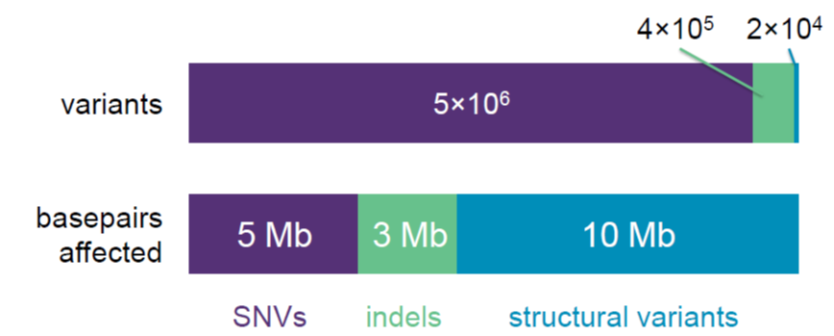

```r
source /home/bioinf/bioinf_archive/43_sovi_storage/Projects/Fettsirte/Run20171109/02_scripts/fileShortcuts.sh

##-------
##sniffles of min5000
##-------
for name in cottens lapraz
   do
    mkdir -p $DATA_ROOT/15_flye/assembly_${name}_min5000/SmrtLink_polished_reference_arrow/freebayes_illumina_polished/rawReads2assembly_ngmlr/sniffles
    $sniffles_root/sniffles -t 10 \
      -m $DATA_ROOT/15_flye/assembly_${name}_min5000/SmrtLink_polished_reference_arrow/freebayes_illumina_polished/rawReads2assembly_ngmlr/raw_${name}_ngmlrMapped_Scaffolds_sorted.bam \
      -v $DATA_ROOT/15_flye/assembly_${name}_min5000/SmrtLink_polished_reference_arrow/freebayes_illumina_polished/rawReads2assembly_ngmlr/sniffles/sniffles_${name}_raw_min5000.vcf

  done
```

### Structural variation caller Pacbio

Pacbio offers an inhouse structural variation caller. This processes includes the steps illustrated in the following graphic:

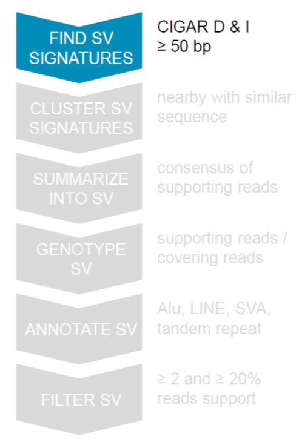

Structrual Variation calling steps implemented by Pacbio

```r
source /home/bioinf/bioinf_archive/43_sovi_storage/Projects/Fettsirte/Run20171109/02_scripts/fileShortcuts.sh

##--------------align with structural variant aware aligner------------------

##cottens
RawBamSubreadscottens=/home/bioinf/bioinf_archive/32_scmi_storage/archivePacBio/fettsirte1_02112017/scratch/pacbio_tmp/tmpWL3QGn/2_7_Cottens_4_E02.tar.gz/m54073_171026_135911.subreads.bam
for name in cottens lapraz
   do
       mkdir -p $DATA_ROOT/15_flye/assembly_${name}_min5000/SmrtLink_polished_reference_arrow/freebayes_illumina_polished/pacbio_VariantCaller/

       #samtools faidx $DATA_ROOT/15_flye/assembly_${name}_min5000/SmrtLink_polished_reference_arrow/freebayes_illumina_polished/freebayesPolishedAssembly/polished_${name}_polishedIllumina.fa

      $pacbio_root/pbsv align \
        $DATA_ROOT/15_flye/assembly_${name}_min5000/SmrtLink_polished_reference_arrow/freebayes_illumina_polished/freebayesPolishedAssembly/polished_${name}_polishedIllumina.fa \
        ${RawBamSubreadscottens} \
        $DATA_ROOT/15_flye/assembly_${name}_min5000/SmrtLink_polished_reference_arrow/freebayes_illumina_polished/pacbio_VariantCaller/pacbio_ref_align_${name}.bam

        ##lapraz
        RawBamSubreadscottens=/home/bioinf/bioinf_archive/32_scmi_storage/archivePacBio/fettsirte1_02112017/scratch/pacbio_tmp/tmpWL3QGn/1_8_La_praz_3_D02.tar.gz/m54073_171026_034928.subreads.bam
    done

##--------------call structural variants from aligned reads------------------
for name in cottens lapraz
   do
    $pacbio_root/pbsv call \
        $DATA_ROOT/15_flye/assembly_${name}_min5000/SmrtLink_polished_reference_arrow/freebayes_illumina_polished/freebayesPolishedAssembly/polished_${name}_polishedIllumina.fa \
        $DATA_ROOT/15_flye/assembly_${name}_min5000/SmrtLink_polished_reference_arrow/freebayes_illumina_polished/rawReads2assembly_ngmlr/raw_${name}_ngmlrMapped_Scaffolds_sorted.bam \
        $DATA_ROOT/15_flye/assembly_${name}_min5000/SmrtLink_polished_reference_arrow/freebayes_illumina_polished/pacbio_VariantCaller/pacbio_variantCall_${name}.vcf
   done
```

#### Nucmer

In order to identify possible repeating regions between and within the genomes

## repeat analysis geneious

In order to better comprehend the structural variation predicition from both pacbio (pbsv) amd sniffles we further extract all repeats from the assembled contigs/genomes. For the repeat analysis we define the following thresholds: - min 500bp long - min identity of 5%

These repeats are used in order to clarify structural variation or spurious regions in the genome. If these regions can be explained by a repeat than we do not consider it as a problem.

#### assembling non mapping reads (plasmid assembly)

The reads which did not map with minimap2 to the flye assembled de novo reference genome are now taken and reassembled in a second stage.

```r
source /home/bioinf/bioinf_archive/43_sovi_storage/Projects/Fettsirte/Run20171109/02_scripts/fileShortcuts.sh
##---------
##plasmid assembly from rawReads
##---------

size=1m
for name in cottens lapraz
   do
      mkdir -p $DATA_ROOT/15_flye/assembly_${name}_raw/plasmidAssembly_flye/{fasta,blast,RawReads2plasmidassembly_minimap2}
      bedtools bamtofastq -i $DATA_ROOT/15_flye/assembly_${name}_raw/rawReads2assembly_minimap2/raw_${name}_minimap2Mapped_sorted_Scaffolds_unampped.bam -fq $DATA_ROOT/15_flye/assembly_${name}_raw/rawReads2assembly_minimap2/raw_${name}_minimap2Mapped_sorted_Scaffolds_unampped.fastq

      $flye_root -t 7 --pacbio-raw $DATA_ROOT/15_flye/assembly_${name}_raw/rawReads2assembly_minimap2/raw_${name}_minimap2Mapped_sorted_Scaffolds_unampped.fastq --out-dir $DATA_ROOT/15_flye/assembly_${name}_raw/plasmidAssembly_flye/fasta --genome-size ${size} -m 5000 -i 3 |tee $DATA_ROOT/15_flye/assembly_${name}_raw/plasmidAssembly_flye/fasta/assemblylog.txt
    size=1m
  done

##---------
##plasmid assembly from min5000
##---------
size=1m
for name in cottens lapraz
   do
      mkdir -p $DATA_ROOT/15_flye/assembly_${name}_min5000/plasmidAssembly_flye/{fasta,blast,RawReads2plasmidassembly_minimap2}
      bedtools bamtofastq -i $DATA_ROOT/15_flye/assembly_${name}_min5000/rawReads2assembly_minimap2/raw_${name}_minimap2Mapped_sorted_Scaffolds_unampped.bam -fq $DATA_ROOT/15_flye/assembly_${name}_min5000/rawReads2assembly_minimap2/raw_${name}_minimap2Mapped_sorted_Scaffolds_unampped.fastq

      $flye_root -t 7 --pacbio-raw $DATA_ROOT/15_flye/assembly_${name}_min5000/rawReads2assembly_minimap2/raw_${name}_minimap2Mapped_sorted_Scaffolds_unampped.fastq --out-dir $DATA_ROOT/15_flye/assembly_${name}_min5000/plasmidAssembly_flye/fasta --genome-size ${size} -m 5000 -i 3 |tee $DATA_ROOT/15_flye/assembly_${name}_min5000/plasmidAssembly_flye/fasta/assemblylog.txt
    size=1m
  done
```

#### blast plasmid assembly (after flye)

In the following we blasted both the contigs.fasta aswell as the scaffolds.fasta file against the prokaryotic ncbi database

```r
source /home/bioinf/bioinf_archive/43_sovi_storage/Projects/Fettsirte/Run20171109/02_scripts/fileShortcuts.sh

###-----------------
##blast rawread flye scaffold assembly (entire procaryotic ncbi database)
###-----------------

for name in cottens lapraz
   do
     blastn -num_threads 2 -max_hsps 1 -max_target_seqs 1 -task megablast -show_gis -query $DATA_ROOT/15_flye/assembly_${name}_raw/plasmidAssembly_flye/fasta/scaffolds.fasta -outfmt "6 qseqid sseqid pident length mismatch gapopen qstart qend sstart send evalue bitscore stitle slen" -db $blastdb/all_prokaryotes -out $DATA_ROOT/15_flye/assembly_${name}_raw/plasmidAssembly_flye/blast/blastAssemblyaginstScaffolds.txt -evalue 0.01 -word_size 64
   done

###-----------------
##blast min5000 flye assembly (entire procaryotic ncbi database)
###-----------------

for name in cottens lapraz
   do
     blastn -num_threads 2 -max_hsps 1 -max_target_seqs 1 -task megablast -show_gis -query $DATA_ROOT/15_flye/assembly_${name}_min5000/plasmidAssembly_flye/fasta/scaffolds.fasta -outfmt "6 qseqid sseqid pident length mismatch gapopen qstart qend sstart send evalue bitscore stitle slen" -db $blastdb/all_prokaryotes -out $DATA_ROOT/15_flye/assembly_${name}_min5000/plasmidAssembly_flye/blast/blastAssemblyaginstScaffolds.txt -evalue 0.01 -word_size 64
   done
```

## plasmid assembly read mapping

```r
source /home/bioinf/bioinf_archive/43_sovi_storage/Projects/Fettsirte/Run20171109/02_scripts/fileShortcuts.sh

##-------
##rawRead mappingminimap2 to rawRead Scaffolds assembly
##-------
for name in cottens lapraz
   do

     ${minimap2_root} -t 12 -ax map-pb $DATA_ROOT/15_flye/assembly_${name}_raw/plasmidAssembly_flye/fasta/scaffolds.fasta $DATA_ROOT/15_flye/assembly_${name}_raw/rawReads2assembly_minimap2/raw_${name}_minimap2Mapped_sorted_Scaffolds_unampped.fastq |samtools sort -@8 -O BAM -o $DATA_ROOT/15_flye/assembly_${name}_raw/plasmidAssembly_flye/RawReads2plasmidassembly_minimap2/unmapped_${name}_minimap2Mapped_plasmid_Scaffolds_sorted.bam - |tee $DATA_ROOT/15_flye/assembly_${name}_raw/plasmidAssembly_flye/RawReads2plasmidassembly_minimap2/unmapped_${name}_minimap2Mapped_plasmid_Scaffolds_sorted.log
   samtools -flagstat $DATA_ROOT/15_flye/assembly_${name}_raw/plasmidAssembly_flye/RawReads2plasmidassembly_minimap2/unmapped_${name}_minimap2Mapped_plasmid_Scaffolds_sorted.bam >> $DATA_ROOT/15_flye/assembly_${name}_raw/plasmidAssembly_flye/RawReads2plasmidassembly_minimap2/unmapped_${name}_minimap2Mapped_plasmid_Scaffolds_sorted.log
   done

##-------
##rawRead mappingminimap2 to min5000 Scaffolds assembly
##-------
for name in cottens lapraz
   do

     ${minimap2_root} -t 12 -ax map-pb $DATA_ROOT/15_flye/assembly_${name}_min5000/plasmidAssembly_flye/fasta/scaffolds.fasta $DATA_ROOT/15_flye/assembly_${name}_min5000/rawReads2assembly_minimap2/raw_${name}_minimap2Mapped_sorted_Scaffolds_unampped.fastq |samtools sort -@8 -O BAM -o $DATA_ROOT/15_flye/assembly_${name}_min5000/plasmidAssembly_flye/RawReads2plasmidassembly_minimap2/unmapped_${name}_minimap2Mapped_plasmid_Scaffolds_sorted.bam - |tee $DATA_ROOT/15_flye/assembly_${name}_min5000/plasmidAssembly_flye/RawReads2plasmidassembly_minimap2/unmapped_${name}_minimap2Mapped_plasmid_Scaffolds_sorted.log
   samtools -flagstat $DATA_ROOT/15_flye/assembly_${name}_min5000/plasmidAssembly_flye/RawReads2plasmidassembly_minimap2/unmapped_${name}_minimap2Mapped_plasmid_Scaffolds_sorted.bam >> $DATA_ROOT/15_flye/assembly_${name}_min5000/plasmidAssembly_flye/RawReads2plasmidassembly_minimap2/unmapped_${name}_minimap2Mapped_plasmid_Scaffolds_sorted.log
   done
```

## Mauve alignment of complete Genomes

```r
source /home/bioinf/bioinf_archive/43_sovi_storage/Projects/Fettsirte/Run20171109/02_scripts/fileShortcuts.sh

##--
##raw reads
##--

for name in cottens lapraz
   do
    location=$(pwd)
    cd $DATA_ROOT/15_flye/assembly_${name}_raw/SmrtLink_polished_reference_arrow/assembly/
    awk '/^>/{s=++d".fasta"} {print > s}' reference_${name}.fasta
    cd $location
  done

##--
##min5000 reads
##--

for name in cottens lapraz
   do
    location=$(pwd)
    cd $DATA_ROOT/15_flye/assembly_${name}_min5000/SmrtLink_polished_reference_arrow/assembly/
    awk '/^>/{s=++d".fasta"} {print > s}' reference_${name}.fasta
    cd $location
  done
```

```r
source /home/bioinf/bioinf_archive/43_sovi_storage/Projects/Fettsirte/Run20171109/02_scripts/fileShortcuts.sh

###---------------------
##Cottens assemblies mauve
###---------------------

##--------------------------Streptococcus mauve-----------------------------

${mauve_root}/progressiveMauve --output=$DATA_ROOT/19_mauve/cottens_min5000/Ster/all.image.out  \
    /home/bioinf/bioinf_archive/43_sovi_storage/Projects/Fettsirte/Run20171109/18_NCBIGenomes/Sthe/fasta/ncbi-genomes-2018-01-29/GCF_900094135.1_ASM90009413v1_genomic.fna \
    /home/bioinf/bioinf_archive/43_sovi_storage/Projects/Fettsirte/Run20171109/18_NCBIGenomes/Sthe/fasta/ncbi-genomes-2018-01-29/GCF_002846155.1_ASM284615v1_genomic.fna \
    /home/bioinf/bioinf_archive/43_sovi_storage/Projects/Fettsirte/Run20171109/18_NCBIGenomes/Sthe/fasta/ncbi-genomes-2018-01-29/GCF_002846075.1_ASM284607v1_genomic.fna \
    /home/bioinf/bioinf_archive/43_sovi_storage/Projects/Fettsirte/Run20171109/18_NCBIGenomes/Sthe/fasta/ncbi-genomes-2018-01-29/GCF_002443035.1_ASM244303v1_genomic.fna \
    /home/bioinf/bioinf_archive/43_sovi_storage/Projects/Fettsirte/Run20171109/18_NCBIGenomes/Sthe/fasta/ncbi-genomes-2018-01-29/GCF_002286255.1_ASM228625v1_genomic.fna \
    /home/bioinf/bioinf_archive/43_sovi_storage/Projects/Fettsirte/Run20171109/18_NCBIGenomes/Sthe/fasta/ncbi-genomes-2018-01-29/GCF_002012365.1_ASM201236v1_genomic.fna \
    /home/bioinf/bioinf_archive/43_sovi_storage/Projects/Fettsirte/Run20171109/18_NCBIGenomes/Sthe/fasta/ncbi-genomes-2018-01-29/GCF_001855705.1_ASM185570v1_genomic.fna \
    /home/bioinf/bioinf_archive/43_sovi_storage/Projects/Fettsirte/Run20171109/18_NCBIGenomes/Sthe/fasta/ncbi-genomes-2018-01-29/GCF_001705585.1_ASM170558v1_genomic.fna \
    /home/bioinf/bioinf_archive/43_sovi_storage/Projects/Fettsirte/Run20171109/18_NCBIGenomes/Sthe/fasta/ncbi-genomes-2018-01-29/GCF_001685375.1_ASM168537v1_genomic.fna \
    /home/bioinf/bioinf_archive/43_sovi_storage/Projects/Fettsirte/Run20171109/18_NCBIGenomes/Sthe/fasta/ncbi-genomes-2018-01-29/GCF_001663795.1_ASM166379v1_genomic.fna \
    /home/bioinf/bioinf_archive/43_sovi_storage/Projects/Fettsirte/Run20171109/18_NCBIGenomes/Sthe/fasta/ncbi-genomes-2018-01-29/GCF_001514435.1_ASM151443v1_genomic.fna \
    /home/bioinf/bioinf_archive/43_sovi_storage/Projects/Fettsirte/Run20171109/18_NCBIGenomes/Sthe/fasta/ncbi-genomes-2018-01-29/GCF_001280285.1_ASM128028v1_genomic.fna \
    /home/bioinf/bioinf_archive/43_sovi_storage/Projects/Fettsirte/Run20171109/18_NCBIGenomes/Sthe/fasta/ncbi-genomes-2018-01-29/GCF_001008015.1_ASM100801v1_genomic.fna \
    /home/bioinf/bioinf_archive/43_sovi_storage/Projects/Fettsirte/Run20171109/18_NCBIGenomes/Sthe/fasta/ncbi-genomes-2018-01-29/GCF_000971665.1_ASM97166v1_genomic.fna \
    /home/bioinf/bioinf_archive/43_sovi_storage/Projects/Fettsirte/Run20171109/18_NCBIGenomes/Sthe/fasta/ncbi-genomes-2018-01-29/GCF_000698885.1_ASM69888v1_genomic.fna \
    /home/bioinf/bioinf_archive/43_sovi_storage/Projects/Fettsirte/Run20171109/18_NCBIGenomes/Sthe/fasta/ncbi-genomes-2018-01-29/GCF_000262675.1_ASM26267v1_genomic.fna \
    /home/bioinf/bioinf_archive/43_sovi_storage/Projects/Fettsirte/Run20171109/18_NCBIGenomes/Sthe/fasta/ncbi-genomes-2018-01-29/GCF_000253395.1_ASM25339v1_genomic.fna \
    /home/bioinf/bioinf_archive/43_sovi_storage/Projects/Fettsirte/Run20171109/18_NCBIGenomes/Sthe/fasta/ncbi-genomes-2018-01-29/GCF_000182875.1_ASM18287v1_genomic.fna \
    /home/bioinf/bioinf_archive/43_sovi_storage/Projects/Fettsirte/Run20171109/18_NCBIGenomes/Sthe/fasta/ncbi-genomes-2018-01-29/GCF_000014485.1_ASM1448v1_genomic.fna \
    /home/bioinf/bioinf_archive/43_sovi_storage/Projects/Fettsirte/Run20171109/18_NCBIGenomes/Sthe/fasta/ncbi-genomes-2018-01-29/GCF_000011845.1_ASM1184v1_genomic.fna \
    /home/bioinf/bioinf_archive/43_sovi_storage/Projects/Fettsirte/Run20171109/18_NCBIGenomes/Sthe/fasta/ncbi-genomes-2018-01-29/GCF_000011825.1_ASM1182v1_genomic.fna \
    /home/bioinf/bioinf_archive/43_sovi_storage/Projects/Fettsirte/Run20171109/15_flye/assembly_cottens_min5000/SmrtLink_polished_reference_arrow/assembly/Ster.fasta

##--------------------------Lactobacillus delbrueckii mauve-----------------------------

${mauve_root}/progressiveMauve --output=$DATA_ROOT/19_mauve/cottens_min5000/Ldel/all.image.out  \
    /home/bioinf/bioinf_archive/43_sovi_storage/Projects/Fettsirte/Run20171109/18_NCBIGenomes/Ldel/fasta/ncbi-genomes-2018-01-29/GCF_900196735.1_Lactobacillus_bulgaricus_ACA-DC_87_genomic.fna \
    /home/bioinf/bioinf_archive/43_sovi_storage/Projects/Fettsirte/Run20171109/18_NCBIGenomes/Ldel/fasta/ncbi-genomes-2018-01-29/GCF_002285775.1_ASM228577v1_genomic.fna \
    /home/bioinf/bioinf_archive/43_sovi_storage/Projects/Fettsirte/Run20171109/18_NCBIGenomes/Ldel/fasta/ncbi-genomes-2018-01-29/GCF_002278095.1_ASM227809v1_genomic.fna \
    /home/bioinf/bioinf_archive/43_sovi_storage/Projects/Fettsirte/Run20171109/18_NCBIGenomes/Ldel/fasta/ncbi-genomes-2018-01-29/GCF_002142575.1_ASM214257v1_genomic.fna \
    /home/bioinf/bioinf_archive/43_sovi_storage/Projects/Fettsirte/Run20171109/18_NCBIGenomes/Ldel/fasta/ncbi-genomes-2018-01-29/GCF_002000885.1_ASM200088v1_genomic.fna \
    /home/bioinf/bioinf_archive/43_sovi_storage/Projects/Fettsirte/Run20171109/18_NCBIGenomes/Ldel/fasta/ncbi-genomes-2018-01-29/GCF_001953135.1_ASM195313v1_genomic.fna \
    /home/bioinf/bioinf_archive/43_sovi_storage/Projects/Fettsirte/Run20171109/18_NCBIGenomes/Ldel/fasta/ncbi-genomes-2018-01-29/GCF_001908415.1_ASM190841v1_genomic.fna \
    /home/bioinf/bioinf_archive/43_sovi_storage/Projects/Fettsirte/Run20171109/18_NCBIGenomes/Ldel/fasta/ncbi-genomes-2018-01-29/GCF_001888985.1_ASM188898v1_genomic.fna \
    /home/bioinf/bioinf_archive/43_sovi_storage/Projects/Fettsirte/Run20171109/18_NCBIGenomes/Ldel/fasta/ncbi-genomes-2018-01-29/GCF_001888965.1_ASM188896v1_genomic.fna \
    /home/bioinf/bioinf_archive/43_sovi_storage/Projects/Fettsirte/Run20171109/18_NCBIGenomes/Ldel/fasta/ncbi-genomes-2018-01-29/GCF_001888945.1_ASM188894v1_genomic.fna \
    /home/bioinf/bioinf_archive/43_sovi_storage/Projects/Fettsirte/Run20171109/18_NCBIGenomes/Ldel/fasta/ncbi-genomes-2018-01-29/GCF_001888925.1_ASM188892v1_genomic.fna \
    /home/bioinf/bioinf_archive/43_sovi_storage/Projects/Fettsirte/Run20171109/18_NCBIGenomes/Ldel/fasta/ncbi-genomes-2018-01-29/GCF_001888905.1_ASM188890v1_genomic.fna \
    /home/bioinf/bioinf_archive/43_sovi_storage/Projects/Fettsirte/Run20171109/18_NCBIGenomes/Ldel/fasta/ncbi-genomes-2018-01-29/GCF_001469775.1_ASM146977v1_genomic.fna \
    /home/bioinf/bioinf_archive/43_sovi_storage/Projects/Fettsirte/Run20171109/18_NCBIGenomes/Ldel/fasta/ncbi-genomes-2018-01-29/GCF_000191165.1_ASM19116v1_genomic.fna \
    /home/bioinf/bioinf_archive/43_sovi_storage/Projects/Fettsirte/Run20171109/18_NCBIGenomes/Ldel/fasta/ncbi-genomes-2018-01-29/GCF_000182835.1_ASM18283v1_genomic.fna \
    /home/bioinf/bioinf_archive/43_sovi_storage/Projects/Fettsirte/Run20171109/18_NCBIGenomes/Ldel/fasta/ncbi-genomes-2018-01-29/GCF_000056065.1_ASM5606v1_genomic.fna \
    /home/bioinf/bioinf_archive/43_sovi_storage/Projects/Fettsirte/Run20171109/18_NCBIGenomes/Ldel/fasta/ncbi-genomes-2018-01-29/GCF_000014405.1_ASM1440v1_genomic.fna \
    /home/bioinf/bioinf_archive/43_sovi_storage/Projects/Fettsirte/Run20171109/15_flye/assembly_cottens_min5000/SmrtLink_polished_reference_arrow/assembly/Ldel.fasta

###---------------------
##lapraz assemblies mauve
###---------------------
```

# Figtree based on the mauve alignment

Apart from the colinearity plot, mauve additionally outputs a newick file with a prelimary tree. This prelimary tree is visualized in figtree. However before doing that the sequences names have to be match to the orignal file names again.

```r
source /home/bioinf/bioinf_archive/43_sovi_storage/Projects/Fettsirte/Run20171109/02_scripts/fileShortcuts.sh

##---
##Ster change name in mauve
##---
sudo rm $DATA_ROOT/19_mauve/cottens_min5000/Ster/all.image.out.guide_tree.renamed
cp $DATA_ROOT/19_mauve/cottens_min5000/Ster/all.image.out.guide_tree $DATA_ROOT/19_mauve/cottens_min5000/Ster/all.image.out.guide_tree.renamed

#for name in cottens lapraz
#   do
    grep -E "Sequence[0-9]+File" $DATA_ROOT/19_mauve/cottens_min5000/Ster/all.image.out |sed 's/#Sequence/seq/g'|sed 's/File//g'|awk -F '[\t/]' '{print $1 , $14}'| sed 's/ /\t/g' |sed 's/.f/_f/g'|sort -r -V > $DATA_ROOT/tmp.txt

    IFS=$'\n'
    while IFS= read -r line;
      do
        tmp1=$(echo $line | cut -f1)
        tmp2=$(echo $line | cut -f2)
        sed -i "s/${tmp1}/${tmp2}/g" $DATA_ROOT/19_mauve/cottens_min5000/Ster/all.image.out.guide_tree.renamed
      done < "$DATA_ROOT/tmp.txt"
 #     rm $DATA_ROOT/tmp.txt
#   done


##---
##Ldel change name in mauve
##---
sudo rm $DATA_ROOT/19_mauve/cottens_min5000/Ldel/all.img.old.guide_tree.renamed
cp $DATA_ROOT/19_mauve/cottens_min5000/Ldel/all.img.old.guide_tree $DATA_ROOT/19_mauve/cottens_min5000/Ldel/all.img.old.guide_tree.renamed

#for name in cottens lapraz
#   do
    grep -E "Sequence[0-9]+File" $DATA_ROOT/19_mauve/cottens_min5000/Ldel/all.img.old |sed 's/#Sequence/seq/g'|sed 's/File//g'|awk -F '[\t/]' '{print $1 , $14}'| sed 's/ /\t/g' |sed 's/.f/_f/g'|sort -r -V > $DATA_ROOT/tmp.txt

    IFS=$'\n'
    while IFS= read -r line;
      do
        tmp1=$(echo $line | cut -f1)
        tmp2=$(echo $line | cut -f2)
        sed -i "s/${tmp1}/${tmp2}/g" $DATA_ROOT/19_mauve/cottens_min5000/Ldel/all.img.old.guide_tree.renamed
      done < "$DATA_ROOT/tmp.txt"
 #     rm $DATA_ROOT/tmp.txt
#   done
```

## Figtree

With Figtree I visualized the preliminary tree outputed from Mauve. The Cottens trees look as following:

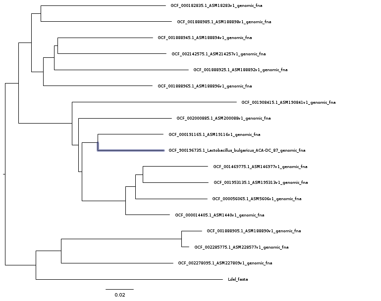

The closest genomes is [ASM227809v1](https://www.ncbi.nlm.nih.gov/assembly/GCF_002278095.1/), which is isolate from ementaler cheese.

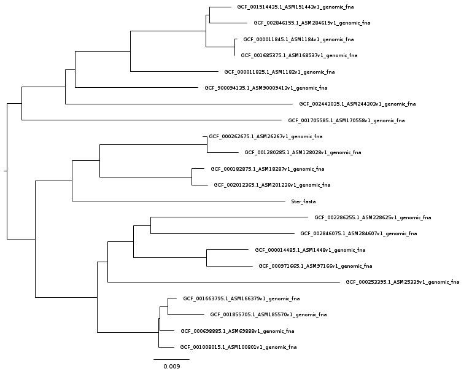

## Prokka

```r
source /home/bioinf/bioinf_archive/43_sovi_storage/Projects/Fettsirte/Run20171109/02_scripts/fileShortcuts.sh

##-------Create Prokka database annotation Lactobacillus-----


mkdir -p $DATA_ROOT/20_genbankDB/{Lactobacillus,Streptococcus}
 $prokka_root/prokka-genbank_to_fasta_db $(find /home/bioinf/bioinf_archive/43_sovi_storage/Projects/Fettsirte/Run20171109/20_genbankDB/Lactobacillus/ncbi-genomes-2018-02-02/|grep "gbff$") > $DATA_ROOT/20_genbankDB/Lactobacillus/ncbi-genomes-2018-02-02/all_Lactobacillus.faa

 cd-hit -i $DATA_ROOT/20_genbankDB/Lactobacillus/ncbi-genomes-2018-02-02/all_Lactobacillus.faa -o $DATA_ROOT/20_genbankDB/Lactobacillus/ncbi-genomes-2018-02-02/Lactobacillus -T 0 -M 0 -g 1 -s 0.8 -c 0.9
 rm -fv $DATA_ROOT/20_genbankDB/Lactobacillus/ncbi-genomes-2018-02-02/all_Lactobacillus.faa $DATA_ROOT/20_genbankDB/Lactobacillus/ncbi-genomes-2018-02-02/Lactobacillus.bak.clstr $DATA_ROOT/20_genbankDB/Lactobacillus/ncbi-genomes-2018-02-02/Lactobacillus.clstr
 makeblastdb -dbtype prot -in $DATA_ROOT/20_genbankDB/Lactobacillus/ncbi-genomes-2018-02-02/Lactobacillus
 mv $DATA_ROOT/20_genbankDB/Lactobacillus/ncbi-genomes-2018-02-02/Lactobacillus.p* /home/bioinf/extradrv/prokka/bin/../db/genus/

##-------Create Prokka database annotation Lactobacillus-----


mkdir -p $DATA_ROOT/20_genbankDB/{Lactobacillus,Streptococcus}
 $prokka_root/prokka-genbank_to_fasta_db $(find /home/bioinf/bioinf_archive/43_sovi_storage/Projects/Fettsirte/Run20171109/20_genbankDB/Streptococcus/ncbi-genomes-2018-02-02/|grep "gbff$") > $DATA_ROOT/20_genbankDB/Streptococcus/ncbi-genomes-2018-02-02/Streptococcus.faa

 cd-hit -i $DATA_ROOT/20_genbankDB/Streptococcus/ncbi-genomes-2018-02-02/Streptococcus.faa -o $DATA_ROOT/20_genbankDB/Streptococcus/ncbi-genomes-2018-02-02/Streptococcus -T 0 -M 0 -g 1 -s 0.8 -c 0.9
 rm -fv $DATA_ROOT/20_genbankDB/Streptococcus/ncbi-genomes-2018-02-02/Streptococcus.faa $DATA_ROOT/20_genbankDB/Streptococcus/ncbi-genomes-2018-02-02/Streptococcus.bak.clstr $DATA_ROOT/20_genbankDB/Streptococcus/ncbi-genomes-2018-02-02/Streptococcus.clstr
 makeblastdb -dbtype prot -in $DATA_ROOT/20_genbankDB/Streptococcus/ncbi-genomes-2018-02-02/Streptococcus
 mv $DATA_ROOT/20_genbankDB/Streptococcus/ncbi-genomes-2018-02-02/Streptococcus.p* /home/bioinf/extradrv/prokka/bin/../db/genus/


##-------Ldel annotation-----
for name in cottens
   do
    mkdir -p $DATA_ROOT/15_flye/assembly_${name}_min5000/SmrtLink_polished_reference_arrow/prokka_genusSpe/Ldel
    $prokka_root/prokka --outdir $DATA_ROOT/15_flye/assembly_${name}_min5000/SmrtLink_polished_reference_arrow/prokka_genusSpe/Ldel --force --usegenus --genus Lactobacillus --locustag LDCO --proteins proteins.faa --evalue 0.001 --addgenes $DATA_ROOT/15_flye/assembly_${name}_min5000/SmrtLink_polished_reference_arrow/assembly/Ldel.fasta

    ##Prokka cannot cope with the pike in the chr name
    sed -i 's/contig_1_arrow/contig_1|arrow/g' $DATA_ROOT/15_flye/assembly_cottens_min5000/SmrtLink_polished_reference_arrow/prokka_genusSpe/Ldel/PROKKA_02022018.gff
   done


##-------Ster annotation-----
for name in cottens
   do
    mkdir -p $DATA_ROOT/15_flye/assembly_${name}_min5000/SmrtLink_polished_reference_arrow/prokka_genusSpe/Ster
    $prokka_root/prokka --outdir $DATA_ROOT/15_flye/assembly_${name}_min5000/SmrtLink_polished_reference_arrow/prokka_genusSpe/Ster --force --usegenus --genus Streptococcus --locustag STCO --proteins proteins.faa --evalue 0.001 --addgenes $DATA_ROOT/15_flye/assembly_${name}_min5000/SmrtLink_polished_reference_arrow/assembly/Ster.fasta

     sed -i 's/scaffold_3_arrow/scaffold_3|arrow/g' $DATA_ROOT/15_flye/assembly_${name}_min5000/SmrtLink_polished_reference_arrow/prokka_genusSpe/Ster/PROKKA_02022018.gff

   done
```

## check Genome assemblies

Visual and manual inspection of assembled genome Workflow: Included tracks: - Pacbio minimap2 mapped reads - IlluminaMiSeq bwa mem mapped reads - Prokka genome annotation - sniffles variant call - Genious repeat analysis (on Michis machine) - GC extremes/content - illumina coverage dip When to exclude spurious mapping regions - Transposase or IS containing regions (potential insertions) - TA rich regions (Illumina has Problem) - Repeat regions - homopolymer (will be polished with Illumina).

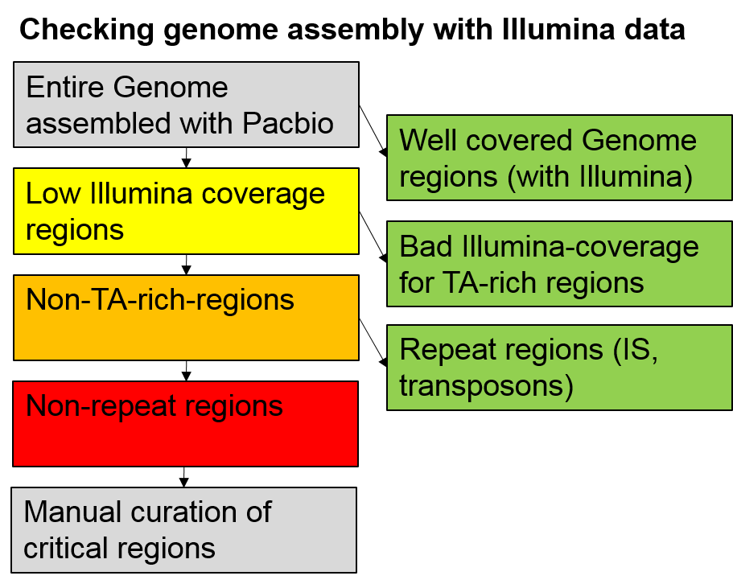

checking genomes assembly with Illumina data

## Abruijn

Abruijn is an assembler from the Pevzner lab that has shown to be very efficient and easy to use with different kinds of sequencing date.

```r
source /home/bioinf/bioinf_archive/43_sovi_storage/Projects/Fettsirte/Run20171109/02_scripts/fileShortcuts.sh

##---------------
##extract raw data
##---------------
for name in cottens lapraz
   do
     tar -zxvf $DATA_ROOT/01_SMRTlink_data/${name}/reads.tar.gz -C $DATA_ROOT/01_SMRTlink_data/${name}/
   done

date=$(date +%Y%m%d)
##---------------
##creat abruijn directories
##---------------
for name in cottens lapraz
   do
    mkdir -p $DATA_ROOT/05_abruijn/${date}assembly_${name}/{quast,fasta}
   done
##---------------
##abruijn assembly with ALL subreads
##---------------
cov=200
for name in cottens lapraz
  do
    $abruijn_root/abruijn -t 16  $DATA_ROOT/01_SMRTlink_data/${name}/reads_${name}_raw.fastq $DATA_ROOT/05_abruijn/assembly_${name}/fasta ${cov} -p pacbio -o 2500
    cov=900
  done

for name in cottens lapraz
   do
    quast.py $DATA_ROOT/05_abruijn/assembly_${name}/fasta/polished_1.fasta -t 8 -o $DATA_ROOT/05_abruijn/assembly_${name}/quast/
   done


##---------------
##abruijn assembly with subreads > 5000bp
##---------------
for name in cottens lapraz
  do
    prinseq-lite.pl -fastq $DATA_ROOT/01_SMRTlink_data/${name}/reads.fastq -min_len 7000 -out_format 3 -out_good $DATA_ROOT/01_SMRTlink_data/${name}/reads_min5000bp  -out_bad null
  done

cov=100
for name in cottens lapraz
  do
    mkdir -p $DATA_ROOT/05_abruijn/assembly_${name}_min5000bp/{fasta,quast}
    $abruijn_root/abruijn -t 10 $DATA_ROOT/01_SMRTlink_data/${name}/reads_min5000bp.fastq $DATA_ROOT/05_abruijn/assembly_${name}_min5000bp/fasta ${cov} -p pacbio -o 2500
    cov=300
  done
##quast
for name in cottens lapraz
   do
    quast.py $DATA_ROOT/05_abruijn/assembly_${name}_min5000bp/fasta/polished_1.fasta -t 8 -o $DATA_ROOT/05_abruijn/assembly_${name}_min5000bp/quast/
   done

##blast
date=20171114
for name in cottens lapraz
   do
     mkdir -p $DATA_ROOT/05_abruijn/assembly_${name}_min5000bp/blast
     $blast_root/blastn -num_threads 16 -max_hsps 1 -max_target_seqs 1 -task megablast -show_gis -query $DATA_ROOT/05_abruijn/assembly_${name}_min5000bp/fasta/polished_1.fasta -outfmt "6 qseqid sseqid pident length mismatch gapopen qstart qend sstart send evalue bitscore stitle slen" -db $blastdb/all_prokaryotes -out $DATA_ROOT/05_abruijn/assembly_${name}_min5000bp/blast/blastAssembly.txt -evalue 0.01 -word_size 64
   done
##---------------
##abruijn assembly with polished reads (preassembly pacbio)
##---------------


cov=100
for name in cottens lapraz
  do
    mkdir -p $DATA_ROOT/05_abruijn/assembly_${name}_preassembledReads/{fasta,quast}
    $abruijn_root/abruijn -t 10 01_SMRTlink_data/${name}/preassembled_reads/preads4falcon.fasta $DATA_ROOT/05_abruijn/assembly_${name}_preassembledReads/fasta ${cov} -p pacbio -i 2 -o 2500
    cov=300
  done
##quast
for name in cottens lapraz
   do
    quast.py $DATA_ROOT/05_abruijn/assembly_${name}_preassembledReads/fasta/polished_1.fasta -t 8 -o $DATA_ROOT/05_abruijn/assembly_${name}_preassembledReads/quast/
   done
##blast
date=20171114
for name in cottens lapraz
   do
     mkdir -p $DATA_ROOT/05_abruijn/assembly_${name}_preassembledReads/blast
     $blast_root/blastn -num_threads 16 -max_hsps 1 -max_target_seqs 1 -task megablast -show_gis -query $DATA_ROOT/05_abruijn/assembly_${name}_preassembledReads/fasta/polished_1.fasta -outfmt "6 qseqid sseqid pident length mismatch gapopen qstart qend sstart send evalue bitscore stitle slen" -db $blastdb/all_prokaryotes -out $DATA_ROOT/05_abruijn/assembly_${name}_preassembledReads/blast/blastAssembly.txt -evalue 0.01 -word_size 64
   done

###==========================
##coverage
###==========================
for name in cottens lapraz
   do
    mkdir -p $DATA_ROOT/05_abruijn/assembly_${name}_min5000bp/coverage
    $bbmap_root/bbwrap.sh ref=$DATA_ROOT/05_abruijn/assembly_${name}_min5000bp/fasta/polished_1.fasta
        $bbmap_root/bbwrap.sh ref=$DATA_ROOT/05_abruijn/assembly_${name}_min5000bp/fasta/polished_1.fasta nodisk in=10 $DATA_ROOT/01_SMRTlink_data/${name}/reads_min5000bp.fastq out=$DATA_ROOT/05_abruijn/assembly_${name}_min5000bp/coverage
  done
```

## Look at assembled contigs

In the following we look at the assembled contigs

```r
source /home/bioinf/bioinf_archive/43_sovi_storage/Projects/Fettsirte/Run20171109/02_scripts/fileShortcuts.sh

for name in cottens lapraz
   do
#    numCon=${grep ">" $DATA_ROOT/05_abruijn/assembly_${name}_min5000bp/fasta/polished_1.fasta}
    echo "The assembly of" ${name}:
    cat $DATA_ROOT/05_abruijn/assembly_${name}_min5000bp/blast/blastAssembly.txt

   done
```

```r
##-----------
##import files
##-----------
assembly_cottens <- read_delim("~/bioinf_archive/43_sovi_storage/Projects/Fettsirte/Run20171109/05_abruijn/assembly_cottens_min5000bp/blast/blastAssembly.txt", "\t", escape_double = FALSE, col_names = c("qseqid" ,"sseqid" ,"pident" ,"length" ,"mismatch", "gapopen", "qstart", "qend", "sstart", "send","evalue" ,"bitscore" ,"stitle"), trim_ws = TRUE)

assembly_lapraz <- read_delim("~/bioinf_archive/43_sovi_storage/Projects/Fettsirte/Run20171109/05_abruijn/assembly_lapraz_min5000bp/blast/blastAssembly.txt", "\t", escape_double = FALSE, col_names = c("qseqid" ,"sseqid" ,"pident" ,"length" ,"mismatch", "gapopen", "qstart", "qend", "sstart", "send","evalue" ,"bitscore" ,"stitle"), trim_ws = TRUE)

##-----------
##add meta information
##-----------
for(i in c("cottens","lapraz")){
    nam <- paste("assembly_",i,sep="")
    name <-   data.frame(do.call('rbind',strsplit(get(nam)$qseqid, split = "_")))
    colnames(name) <- c("circularity","number","contigLength","ContigCoverage")
    assign(nam,cbind(get(nam),name))
}
##-----------
##add meta information
##-----------

for(i in c("cottens","lapraz")){
    nam <- paste("assembly_",i,sep="")
    nam_2 <- paste("reduced_assembly_",i,sep="")
    nam_2 <- as.data.frame(get(nam)) %>%
    dplyr::select(qseqid, circularity, contigLength, ContigCoverage,bitscore,sseqid,stitle)
    print(c("The Best hits for the ",i, "assembly are the following"))
    kable(nam_2)
}
```

## Minimap2 and Miniasm from Heng Li

The recently developed Minimap2 (Mapper) amd Miniasm (overlaper) are much faster as all other methods. However it did not improve the Metagenomic assembly. Therefor the chunk was removed on the 24.1.2018. The files however still exist.

## Metaspades and megahit as a Debruijn assembler specifically for metagenomic datasets

Although Debruijn assemblers are orignally meant for short and low error rate sequences we give it a try on the reads >5000bp.

Nor the Metaspades aswell as the megahit assembly did not work for the pacbio only data. Therefor it was removed on the 24.1.2018

## sprai error correction

Sprai is able to do the error correction without assembly. Additionally spray can check for circularity of an assembly. However this code chunk was removed on the 24.1.2018.

# Binning reads/preassembled reads

Different binning approachs have been applied. Amongst the most common ones are: the Tetranucleotide binning (Iverson et al. 2012) and the coverage based binning (Albertsen et al. 2013). However it has been noticed that both entities apply only to entities with a extreme skew. Further it is unlikely that both the coverage aswell as the tetranucleotide distribution is consisten over the entire genome. Therefore these methods might additionally bias the assembly. An additional binning method could be based pn the co-abundance of a species in mutliple many samples. This method relies on a large number of replicates in order to cluster and assemble co-abundant clusters (H. B. Nielsen et al. 2014)

## Own Blobology on preassemblies

The blobolgoy is based on te preassembled reads. We need the following data: 1. Preassembled reads coverage (#RawReads minimap2 aligned to preassembled reads) 2. GC% of preassembled reads 3. Minimap2 aligning of preassembled reads to Flye assembly

After this we make a plot in R.

```r
source /home/bioinf/bioinf_archive/43_sovi_storage/Projects/Fettsirte/Run20171109/02_scripts/fileShortcuts.sh

###==========================
##1. Preassembled reads coverage
###==========================
##-------
##index reference genome
##-------

for name in cottens lapraz
   do
    $minimap2_root -d $DATA_ROOT/01_SMRTlink_data/${name}/preassembled_reads/preads4falcon.mmi $DATA_ROOT/01_SMRTlink_data/${name}/preassembled_reads/preads4falcon.fasta
   done

##-------
##read mapping
##-------
for name in cottens lapraz
   do
     mkdir -p $DATA_ROOT/16_blobologyOwn/preassembly_${name}/{01_minimapRawReads,02_GC,03_minimapAgainstFlye}
     mkdir -p $DATA_ROOT/16_blobologyOwn/preassembly_${name}/01_minimapRawReads/bamqc

     ${minimap2_root} -ax map-pb $DATA_ROOT/01_SMRTlink_data/${name}/preassembled_reads/preads4falcon.fasta $DATA_ROOT/01_SMRTlink_data/${name}/reads_${name}_raw.fastq |samtools sort -@8 -O BAM -o $DATA_ROOT/16_blobologyOwn/preassembly_${name}/01_minimapRawReads/raw_${name}_mapped_preassembly_sorted.bam - | tee $DATA_ROOT/16_blobologyOwn/preassembly_${name}/01_minimapRawReads/raw_${name}_mapped_preassembly_sorted.log

      $QUAL_ROOT/qualimap bamqc -bam $DATA_ROOT/16_blobologyOwn/preassembly_${name}/01_minimapRawReads/raw_${name}_mapped_preassembly_sorted.bam -outdir $DATA_ROOT/16_blobologyOwn/preassembly_${name}/01_minimapRawReads/bamqc/ --java-mem-size=2G

   done

for name in cottens lapraz
   do
    samtools view $DATA_ROOT/16_blobologyOwn/preassembly_${name}/01_minimapRawReads/raw_${name}_mapped_preassembly_sorted.bam |cut -f 3 |sort |uniq -c |awk '{$1=$1};1'| sed -e 's/ /\t/g' > $DATA_ROOT/16_blobologyOwn/preassembly_${name}/01_minimapRawReads/coverage_${name}_preassembled.txt
   done

###==========================
##2. GC% of preassembled reads
###==========================
for name in cottens lapraz
   do
    infoseq -nocolumns -delimiter , -auto -only -name -length -pgc $DATA_ROOT/01_SMRTlink_data/${name}/preassembled_reads/preads4falcon.fasta > $DATA_ROOT/16_blobologyOwn/preassembly_${name}/02_GC/gc_content_${name}_preassemeled.txt

    #prinseq-lite.pl -stats_dinuc -fasta $DATA_ROOT/01_SMRTlink_data/${name}/preassembled_reads/preads4falcon.fasta > $DATA_ROOT/16_blobologyOwn/preassembly_${name}/02_GC/gc_content_${name}_preassemeled.txt
  done

###==========================
##3. Minimap2 aligning of preassembled reads to Flye assembly
###==========================
for name in cottens lapraz
   do
     mkdir -p $DATA_ROOT/16_blobologyOwn/preassembly_${name}/03_minimapAgainstFlye/bamqc

    ${minimap2_root} -ax map-pb $DATA_ROOT/15_flye/assembly_${name}_min5000/fasta/scaffolds.fasta $DATA_ROOT/01_SMRTlink_data/${name}/preassembled_reads/preads4falcon.fasta |samtools sort -@8 -O BAM -o $DATA_ROOT/16_blobologyOwn/preassembly_${name}/03_minimapAgainstFlye/preassembled_${name}_mapped_FlyeAssembly_sorted.bam - | tee $DATA_ROOT/16_blobologyOwn/preassembly_${name}/03_minimapAgainstFlye/preassembled_${name}_mapped_FlyeAssembly_sorted.log

    $QUAL_ROOT/qualimap bamqc -bam $DATA_ROOT/16_blobologyOwn/preassembly_${name}/03_minimapAgainstFlye/preassembled_${name}_mapped_FlyeAssembly_sorted.bam -outdir $DATA_ROOT/16_blobologyOwn/preassembly_${name}/03_minimapAgainstFlye/bamqc/ --java-mem-size=2G

    done

for name in cottens lapraz
   do
    samtools view $DATA_ROOT/16_blobologyOwn/preassembly_${name}/03_minimapAgainstFlye/preassembled_${name}_mapped_FlyeAssembly_sorted.bam |awk '{print $1 , $3}'  > $DATA_ROOT/16_blobologyOwn/preassembly_${name}/03_minimapAgainstFlye/mapping_${name}_preassembled.txt
   done
```

```r
##preassembly coverage
coverage_preassembly_cottens <- read_delim("/home/bioinf/bioinf_archive/43_sovi_storage/Projects/Fettsirte/Run20171109/16_blobologyOwn/preassembly_cottens/01_minimapRawReads/coverage_cottens_preassembled.txt", "\t", escape_double = FALSE, col_names = c("hits","name"),  trim_ws = TRUE)
coverage_preassembly_cottens <- coverage_preassembly_cottens[-1,]
coverage_preassembly_lapraz <- read_delim("/home/bioinf/bioinf_archive/43_sovi_storage/Projects/Fettsirte/Run20171109/16_blobologyOwn/preassembly_lapraz/01_minimapRawReads/coverage_lapraz_preassembled.txt", "\t", escape_double = FALSE, col_names = c("hits","name"),  trim_ws = TRUE)
coverage_preassembly_lapraz <- coverage_preassembly_lapraz[-1,]

##gc content
gc_cottens <- read_csv("/home/bioinf/bioinf_archive/43_sovi_storage/Projects/Fettsirte/Run20171109/16_blobologyOwn/preassembly_cottens/02_GC/gc_content_cottens_preassemeled.txt")
gc_lapraz <- read_csv("/home/bioinf/bioinf_archive/43_sovi_storage/Projects/Fettsirte/Run20171109/16_blobologyOwn/preassembly_lapraz/02_GC/gc_content_lapraz_preassemeled.txt")

##reference contig

mapping_cottens_preassembled <- read_delim("/home/bioinf/bioinf_archive/43_sovi_storage/Projects/Fettsirte/Run20171109/16_blobologyOwn/preassembly_cottens/03_minimapAgainstFlye/mapping_cottens_preassembled.txt",  " ", escape_double = FALSE, col_names = c("read","scaffold"),trim_ws = TRUE)
mapping_lapraz_preassembled <- read_delim("/home/bioinf/bioinf_archive/43_sovi_storage/Projects/Fettsirte/Run20171109/16_blobologyOwn/preassembly_lapraz/03_minimapAgainstFlye/mapping_lapraz_preassembled.txt",  " ", escape_double = FALSE, col_names = c("read","scaffold"),trim_ws = TRUE)

##ordering contigs Cottens
all(mapping_cottens_preassembled$read %in% coverage_preassembly_cottens$name)
all(mapping_cottens_preassembled$read %in% gc_cottens$Name)

no_cov <- nrow(mapping_cottens_preassembled)-nrow(coverage_preassembly_cottens)
print(c(no_cov,"contigs do not have a coverage"))

gc_cottens <- gc_cottens[match(coverage_preassembly_cottens$name,gc_cottens$Name),]
mapping_cottens_preassembled <- mapping_cottens_preassembled[match(coverage_preassembly_cottens$name,mapping_cottens_preassembled$read),]

all(mapping_cottens_preassembled$read %in% coverage_preassembly_cottens$name)
all(mapping_cottens_preassembled$read %in% gc_cottens$Name)

left_contigs <- nrow(mapping_cottens_preassembled)
print(c("Finally, there are ",left_contigs,"contigs left"))


##ordering contigs lapraz

all(mapping_lapraz_preassembled$read %in% coverage_preassembly_lapraz$name)
all(mapping_lapraz_preassembled$read %in% gc_lapraz$Name)

no_cov <- nrow(mapping_lapraz_preassembled)-nrow(coverage_preassembly_lapraz)
print(c(no_cov,"contigs do not have a coverage"))

gc_lapraz <- gc_lapraz[match(coverage_preassembly_lapraz$name,gc_lapraz$Name),]
mapping_lapraz_preassembled <- mapping_lapraz_preassembled[match(coverage_preassembly_lapraz$name,mapping_lapraz_preassembled$read),]

all(mapping_lapraz_preassembled$read %in% coverage_preassembly_lapraz$name)
all(mapping_lapraz_preassembled$read %in% gc_lapraz$Name)

left_contigs <- nrow(mapping_lapraz_preassembled)
print(c("Finally, there are ",left_contigs,"contigs left"))

##creat dataframe cottens

final_df_cottens <- data.frame(name=mapping_cottens_preassembled$read,coverage=coverage_preassembly_cottens$hits,gc=gc_cottens$`%GC`,length=gc_cottens$Length,mapping=mapping_cottens_preassembled$scaffold)

##creat dataframe lapraz

final_df_lapraz <- data.frame(name=mapping_lapraz_preassembled$read,coverage=coverage_preassembly_lapraz$hits,gc=gc_lapraz$`%GC`,length=gc_lapraz$Length,mapping=mapping_lapraz_preassembled$scaffold)

##plot cottens

scatterPlot <- ggplot(data = final_df_cottens,aes(x=coverage,y=gc,color=mapping))+
  geom_point()+
  theme_bw()+
  theme(legend.title=element_blank())

# Marginal density plot of x (top panel)
xdensity <- ggplot(data = final_df_cottens,aes(x=coverage,fill=mapping)) +
  geom_density(alpha=.5) +
  scale_x_continuous(name="") +
  theme_bw()+
  theme(legend.position="none",axis.text.x=element_blank())
# xdensity
# Marginal density plot of y (right panel)
ydensity <- ggplot(data = final_df_cottens, aes(x=gc, fill=mapping)) +
  geom_density(alpha=.5) +
  scale_x_continuous(name="")+
  theme_bw()+
  coord_flip()+
  theme(legend.position="none",axis.text.x=element_blank())
# ydensity

legend <- g_legend(scatterPlot)

grid.arrange(xdensity, legend,scatterPlot+theme(legend.position="none"), ydensity,
        ncol=2, nrow=2, widths=c(4, 1.4), heights=c(1.4, 4))

##plot lapraz
#
# scatterPlot <- ggplot(data = final_df_lapraz,aes(x=coverage,y=gc,color=mapping))+
#   geom_point()+
#   theme_bw()+
#   theme(legend.title=element_blank())
#
# # Marginal density plot of x (top panel)
# xdensity <- ggplot(data = final_df_lapraz,aes(x=coverage,fill=mapping)) +
#   geom_density(alpha=.5) +
#   scale_x_continuous(name="") +
#   theme_bw()+
#   theme(legend.position="none",axis.text.x=element_blank())
# # xdensity
# # Marginal density plot of y (right panel)
# ydensity <- ggplot(data = final_df_lapraz, aes(x=gc, fill=mapping)) +
#   geom_density(alpha=.5) +
#   scale_x_continuous(name="")+
#   theme_bw()+
#   coord_flip()+
#   theme(legend.position="none",axis.text.x=element_blank())
# # ydensity
#
# legend <- g_legend(scatterPlot)
#
# grid.arrange(xdensity, legend,scatterPlot+theme(legend.position="none"), ydensity,
#         ncol=2, nrow=2, widths=c(4, 1.4), heights=c(1.4, 4))
```

## Nucmer to align different assemblies against eachother

The large limitation in Assembling genomes as well as metagenomes is the ability to sequence larger than repeats. For a single genome this means the read length needs to be sufficiently long to span the largest repeat. However for metagenome assembly there is additonally to the intragenomic repeat a difficulty to dinstinguish inter genomic repeats (Olson et al. 2017). In order to look at the repeats

```r
source /home/bioinf/bioinf_archive/43_sovi_storage/Projects/Fettsirte/Run20171109/02_scripts/fileShortcuts.sh

###==========================
##combine delbruecki and streptococcus from lapraz abruijn assembly
###==========================

mkdir -p $DATA_ROOT/11_nucmer_repeat/cottens_abruijn_delbruecki_streptococcus/{fasta,nucmer,deltaFiltered}

cat $DATA_ROOT/05_abruijn/assembly_cottens_min5000bp/fasta/multifasta/linear_1_len1924117_cov316.fa $DATA_ROOT/05_abruijn/assembly_cottens_min5000bp/fasta/multifasta/linear_2_len2265372_cov167.fa > $DATA_ROOT/11_nucmer_repeat/cottens_abruijn_delbruecki_streptococcus/fasta/reads.fa

###==========================
##nucmer
###==========================
cd $DATA_ROOT/11_nucmer_repeat/cottens_abruijn_delbruecki_streptococcus/nucmer/
nucmer -maxmatch -nosimplify $DATA_ROOT/11_nucmer_repeat/cottens_abruijn_delbruecki_streptococcus/fasta/reads.fa $DATA_ROOT/11_nucmer_repeat/cottens_abruijn_delbruecki_streptococcus/fasta/reads.fa
cd $DATA_ROOT

###==========================
##delta filter
###==========================
mkdir -p $DATA_ROOT/11_nucmer_repeat/cottens_abruijn_delbruecki_streptococcus/{fasta,nucmer,deltaFiltered}
delta-filter -i 85 -l 3000  $DATA_ROOT/11_nucmer_repeat/cottens_abruijn_delbruecki_streptococcus/nucmer/out.delta > $DATA_ROOT/11_nucmer_repeat/cottens_abruijn_delbruecki_streptococcus/deltaFiltered/filtered.txt
##split files
cd $DATA_ROOT/11_nucmer_repeat/cottens_abruijn_delbruecki_streptococcus/deltaFiltered/
split -t ">" -l 1 $DATA_ROOT/11_nucmer_repeat/cottens_abruijn_delbruecki_streptococcus/deltaFiltered/filtered.txt
cd $DATA_ROOT
##extract only necassary files
grep "[[:space:]]" $DATA_ROOT/11_nucmer_repeat/cottens_abruijn_delbruecki_streptococcus/deltaFiltered/xac | awk 'BEGIN {OFS ="\t"} {print "Sterm" , $1 , $2 , "Ldel" , $3 , $4}' > $DATA_ROOT/11_nucmer_repeat/cottens_abruijn_delbruecki_streptococcus/deltaFiltered/links.txt
tail -1 $DATA_ROOT/11_nucmer_repeat/cottens_abruijn_delbruecki_streptococcus/deltaFiltered/links.txt > $DATA_ROOT/11_nucmer_repeat/cottens_abruijn_delbruecki_streptococcus/deltaFiltered/link.txt
rm $DATA_ROOT/11_nucmer_repeat/cottens_abruijn_delbruecki_streptococcus/deltaFiltered/links.txt

###==========================
##Lhev and Sterm repeats
###==========================
mkdir -p $DATA_ROOT/11_nucmer_repeat/Lhev_Sterm/{01_fasta,nucmer,deltaFiltered}
cat $DATA_ROOT/11_nucmer_repeat/delbruecki_helveticus/01_fasta/Lhev.fasta $DATA_ROOT/05_abruijn/assembly_cottens_min5000bp/fasta/multifasta/linear_1_len1924117_cov316.fa > $DATA_ROOT/11_nucmer_repeat/Lhev_Sterm/01_fasta/Lhev_Sterm.fasta
##nucmer
cd $DATA_ROOT/11_nucmer_repeat/Lhev_Sterm/nucmer/
nucmer -maxmatch -nosimplify $DATA_ROOT/11_nucmer_repeat/Lhev_Sterm/01_fasta/Lhev_Sterm.fasta $DATA_ROOT/11_nucmer_repeat/Lhev_Sterm/01_fasta/Lhev_Sterm.fasta
cd $DATA_ROOT
##delta-filter
delta-filter -i 85 -l 3000  $DATA_ROOT/11_nucmer_repeat/Lhev_Sterm/nucmer/out.delta >  $DATA_ROOT/11_nucmer_repeat/Lhev_Sterm/deltaFiltered/filtered.txt
##split files
cd $DATA_ROOT/11_nucmer_repeat/Lhev_Sterm//deltaFiltered/
split -t ">" -l 1 $DATA_ROOT/11_nucmer_repeat/Lhev_Sterm/deltaFiltered/filtered.txt
cd $DATA_ROOT
##extract only necassary files
grep "[[:space:]]" $DATA_ROOT/11_nucmer_repeat/Lhev_Sterm/deltaFiltered/xac | awk 'BEGIN {OFS ="\t"} {print "Sterm" , $1 , $2 , "Lhev" , $3 , $4}' > $DATA_ROOT/11_nucmer_repeat/Lhev_Sterm/deltaFiltered/links.txt
tail -1 $DATA_ROOT/11_nucmer_repeat/Lhev_Sterm/deltaFiltered/links.txt > $DATA_ROOT/11_nucmer_repeat/Lhev_Sterm/deltaFiltered/link.txt
rm $DATA_ROOT/11_nucmer_repeat/Lhev_Sterm/deltaFiltered/links.txt
##size of repeats
awk '{print $3-$2}' $DATA_ROOT/11_nucmer_repeat/Lhev_Sterm/deltaFiltered/link.txt


###==========================
##Lhev and delbruecki repeats
###==========================
mkdir -p $DATA_ROOT/11_nucmer_repeat/delbruecki_helveticus/{01_fasta,nucmer,deltaFiltered}
cat $DATA_ROOT/11_nucmer_repeat/delbruecki_helveticus/01_fasta/Lhev.fasta $DATA_ROOT/05_abruijn/assembly_cottens_min5000bp/fasta/multifasta/linear_2_len2265372_cov167.fa > $DATA_ROOT/11_nucmer_repeat/delbruecki_helveticus/01_fasta/Lhev_del.fasta
##nucmer
cd $DATA_ROOT/11_nucmer_repeat/delbruecki_helveticus/nucmer/
nucmer -maxmatch -nosimplify $DATA_ROOT/11_nucmer_repeat/delbruecki_helveticus/01_fasta/Lhev_del.fasta $DATA_ROOT/11_nucmer_repeat/delbruecki_helveticus/01_fasta/Lhev_del.fasta
cd $DATA_ROOT
##delta-filter
delta-filter -i 85 -l 3000  $DATA_ROOT/11_nucmer_repeat/delbruecki_helveticus/nucmer/out.delta >  $DATA_ROOT/11_nucmer_repeat/delbruecki_helveticus/deltaFiltered/filtered.txt
##split files
cd $DATA_ROOT/11_nucmer_repeat/delbruecki_helveticus/deltaFiltered/
split -t ">" -l 1 $DATA_ROOT/11_nucmer_repeat/delbruecki_helveticus/deltaFiltered/filtered.txt
cd $DATA_ROOT
##extract only necassary files
grep "[[:space:]]" $DATA_ROOT/11_nucmer_repeat/delbruecki_helveticus/deltaFiltered/xac | awk 'BEGIN {OFS ="\t"} {print "Ldel" , $1 , $2 , "Lhev" , $3 , $4}' > $DATA_ROOT/11_nucmer_repeat/delbruecki_helveticus/deltaFiltered/links.txt
tail -1 $DATA_ROOT/11_nucmer_repeat/delbruecki_helveticus/deltaFiltered/links.txt > $DATA_ROOT/11_nucmer_repeat/delbruecki_helveticus/deltaFiltered/link.txt
rm $DATA_ROOT/11_nucmer_repeat/delbruecki_helveticus/deltaFiltered/links.txt

###==========================
##cat all three intergenomic repeat files together
###==========================

cat $DATA_ROOT/11_nucmer_repeat/delbruecki_helveticus/deltaFiltered/link.txt $DATA_ROOT/11_nucmer_repeat/Lhev_Sterm/deltaFiltered/link.txt $DATA_ROOT/11_nucmer_repeat/cottens_abruijn_delbruecki_streptococcus/deltaFiltered/link.txt > $DATA_ROOT/11_nucmer_repeat/links.txt


###==========================
##Lhev and Lacido repeats
###==========================
mkdir -p $DATA_ROOT/11_nucmer_repeat/Lhev_Lacido/{01_fasta,nucmer,deltaFiltered}
cat $DATA_ROOT/11_nucmer_repeat/delbruecki_helveticus/01_fasta/Lhev.fasta $DATA_ROOT/11_nucmer_repeat/Lhev_Lacido/01_fasta/Lacido.fasta > $DATA_ROOT/11_nucmer_repeat/Lhev_Lacido/01_fasta/Lhev_Lacido.fasta
##nucmer
cd $DATA_ROOT/11_nucmer_repeat/Lhev_Lacido/nucmer/
nucmer -maxmatch -nosimplify $DATA_ROOT/11_nucmer_repeat/Lhev_Lacido/01_fasta/Lhev_Lacido.fasta $DATA_ROOT/11_nucmer_repeat/Lhev_Lacido/01_fasta/Lhev_Lacido.fasta
cd $DATA_ROOT
##delta-filter
delta-filter -i 85 -l 3000  $DATA_ROOT/11_nucmer_repeat/Lhev_Lacido/nucmer/out.delta >  $DATA_ROOT/11_nucmer_repeat/Lhev_Lacido/deltaFiltered/filtered.txt
##split files
cd $DATA_ROOT/11_nucmer_repeat/Lhev_Lacido/deltaFiltered/
split -t ">" -l 1 $DATA_ROOT/11_nucmer_repeat/Lhev_Lacido/deltaFiltered/filtered.txt
cd $DATA_ROOT
##extract only necassary files
grep "[[:space:]]" $DATA_ROOT/11_nucmer_repeat/Lhev_Lacido/deltaFiltered/xac | awk 'BEGIN {OFS ="\t"} {print "Lhev" , $1 , $2 , "Lacido" , $3 , $4}' > $DATA_ROOT/11_nucmer_repeat/Lhev_Lacido/deltaFiltered/links.txt
tail -18 $DATA_ROOT/11_nucmer_repeat/Lhev_Lacido/deltaFiltered/links.txt > $DATA_ROOT/11_nucmer_repeat/Lhev_Lacido/deltaFiltered/link.txt
rm $DATA_ROOT/11_nucmer_repeat/Lhev_Lacido/deltaFiltered/links.txt

###==========================
##Lhev repeats
###==========================

##extract only necassary files
grep "[[:space:]]" $DATA_ROOT/11_nucmer_repeat/Lhev_Lacido/deltaFiltered/xab | awk 'BEGIN {OFS ="\t"} {print "Lhev" , $1 , $2 , "Lhev" , $3 , $4}' > $DATA_ROOT/11_nucmer_repeat/Lhev_Lacido/deltaFiltered/links_intra.txt
tail -2 $DATA_ROOT/11_nucmer_repeat/Lhev_Lacido/deltaFiltered/links_intra.txt > $DATA_ROOT/11_nucmer_repeat/Lhev_Lacido/deltaFiltered/link_intra.txt
rm $DATA_ROOT/11_nucmer_repeat/Lhev_Lacido/deltaFiltered/links_intra.txt

###==========================
##Ldel repeats
###==========================

##extract only necassary files
grep "[[:space:]]" $DATA_ROOT/11_nucmer_repeat/delbruecki_helveticus/deltaFiltered/xab | awk 'BEGIN {OFS ="\t"} {print "Ldel" , $1 , $2 , "Ldel" , $3 , $4}' > $DATA_ROOT/11_nucmer_repeat/delbruecki_helveticus/deltaFiltered/links_intra.txt
tail -18 $DATA_ROOT/11_nucmer_repeat/delbruecki_helveticus/deltaFiltered/links_intra.txt > $DATA_ROOT/11_nucmer_repeat/delbruecki_helveticus/deltaFiltered/link_intra.txt
rm $DATA_ROOT/11_nucmer_repeat/delbruecki_helveticus/deltaFiltered/links_intra.txt


###==========================
##Sterm repeats
###==========================

grep "[[:space:]]" $DATA_ROOT/11_nucmer_repeat/Lhev_Sterm/deltaFiltered/xab | awk 'BEGIN {OFS ="\t"} {print "Sterm" , $1 , $2 , "Sterm" , $3 , $4}' > $DATA_ROOT/11_nucmer_repeat/Lhev_Sterm/deltaFiltered/links_intra.txt
tail -18 $DATA_ROOT/11_nucmer_repeat/Lhev_Sterm/deltaFiltered/links_intra.txt > $DATA_ROOT/11_nucmer_repeat/Lhev_Sterm/deltaFiltered/link_intra.txt
rm $DATA_ROOT/11_nucmer_repeat/Lhev_Sterm/deltaFiltered/links_intra.txt
##size of repeats

###==========================
##cat all three intragenomic repeat files together
###==========================

cat $DATA_ROOT/11_nucmer_repeat/delbruecki_helveticus/deltaFiltered/link_intra.txt $DATA_ROOT/11_nucmer_repeat/Lhev_Sterm/deltaFiltered/link_intra.txt $DATA_ROOT/11_nucmer_repeat/Lhev_Lacido/deltaFiltered/link_intra.txt > $DATA_ROOT/11_nucmer_repeat/link_intra.txt
```

## Blasting the assemblages against the entire prokaryotic complete genome database

After having assembled the genomes with different assembly algorithms we continue to blast all contigs against the current prokaryotic complete genome database. In the following we creat the complete genome database and locally BLAST against it.

```r
source /home/bioinf/bioinf_archive/43_sovi_storage/Projects/Fettsirte/Run20171109/02_scripts/fileShortcuts.sh

###-----------------
##create complete prokaryotic genomes blast database
###-----------------
ls $blastdb | awk -F. '{print $1, $2}' | sed 's/ /./g'> $blastdb/filelist.txt

for FILE in `cat $blastdb/filelist.txt`
  do
    gunzip -c $blastdb/${FILE}*
    perl $DATA_ROOT/02_scripts/gbk2fasta.pl < $blastdb/${FILE}* >> $blastdb/all_prokaryotes.fa
    rm $blastdb/${FILE}*.gbff
  done


##creat blastdb
$blast_root/makeblastdb -max_file_sz 10GB -in $blastdb/all_prokaryotes.fa -out $blastdb/all_prokaryotes -parse_seqids -dbtype nucl
###-----------------
##blast Hgap4 assembly
###-----------------

date=20171114
for name in cottens lapraz
   do
     mkdir -p $DATA_ROOT/04_HGAP4/${date}assembly_${name}/blast/
     $blast_root/blastn -num_threads 16 -max_hsps 2 -max_target_seqs 2 -task megablast -show_gis -query $DATA_ROOT/04_HGAP4/${date}assembly_${name}/fasta/assembly.fasta -outfmt "6 qseqid sseqid pident length mismatch gapopen qstart qend sstart send evalue bitscore stitle slen" -db $blastdb/all_prokaryotes -out $DATA_ROOT/04_HGAP4/${date}assembly_${name}/blast/blastAssembly_04.txt -evalue 0.01 -word_size 64
   done
##sort for best hit
#sort -k1,1 -k12,12nr -k11,11n  $DATA_ROOT/04_HGAP4/20171114assembly_lapraz/blast/blastAssembly_03.txt | sort -u -k1,1 --merge

date=20171114
for name in cottens lapraz
   do
      echo species level for ${name}
           sort -k1,1 -k12,12nr -k11,11n $DATA_ROOT/04_HGAP4/${date}assembly_${name}/blast/blastAssembly_04.txt | sort -u -k1,1 --merge|cut -f 13|awk 'BEGIN {OFS=" "}; {print $1, $2}'|sort|uniq -c
      echo strain level for ${name}
      sort -k1,1 -k12,12nr -k11,11n  $DATA_ROOT/04_HGAP4/${date}assembly_${name}/blast/blastAssembly_04.txt | sort -u -k1,1 --merge|cut -f 13|sort| uniq -c
   done

###-----------------
##blast ABruijn assembly
###-----------------

date=20171114
for name in cottens lapraz
   do
     mkdir -p $DATA_ROOT/05_abruijn/assembly_${name}/blast/
     $blast_root/blastn -num_threads 16 -max_hsps 2 -max_target_seqs 2 -task megablast -show_gis -query   $DATA_ROOT/05_abruijn/assembly_${name}/fasta/polished_1.fasta -outfmt "6 qseqid sseqid pident length mismatch gapopen qstart qend sstart send evalue bitscore stitle slen" -db $blastdb/all_prokaryotes -out $DATA_ROOT/05_abruijn/assembly_${name}/blast/blastAssembly.txt -evalue 0.01 -word_size 64
   done
##sort for best hit
#sort -k1,1 -k12,12nr -k11,11n  $DATA_ROOT/05_abruijn/assembly_lapraz/blast/blastAssembly.txt | sort -u -k1,1 --merge
##uniq strains
#sort -k1,1 -k12,12nr -k11,11n  $DATA_ROOT/05_abruijn/assembly_lapraz/blast/blastAssembly.txt | sort -u -k1,1 --merge|cut -f 13|sort| uniq -c
##species

date=20171114
for name in cottens lapraz
   do
      echo species level for ${name}
           sort -k1,1 -k12,12nr -k11,11n  $DATA_ROOT/05_abruijn/assembly_${name}/blast/blastAssembly.txt | sort -u -k1,1 --merge|cut -f 13|awk 'BEGIN {OFS=" "}; {print $1, $2}'|sort|uniq -c
      echo strain level for ${name}
      sort -k1,1 -k12,12nr -k11,11n  $DATA_ROOT/05_abruijn/assembly_lapraz/blast/blastAssembly.txt | sort -u -k1,1 --merge|cut -f 13|sort| uniq -c
   done
```

## Align raw reads to assembled genomes

```r
source /home/bioinf/bioinf_archive/43_sovi_storage/Projects/Fettsirte/Run20171109/02_scripts/fileShortcuts.sh
##=============
##minimap2
##=============

##-------
##index reference genome
##-------

#for name in cottens lapraz
#   do
#    $minimap2_root -d $DATA_ROOT/05_abruijn/assembly_${name}/fasta/polished_1.mmi $DATA_ROOT/05_abruijn/assembly_${name}/fasta/polished_1.fasta
#   done

##-------
##read mapping
##-------
for name in cottens lapraz
   do
     mkdir -p $DATA_ROOT/05_abruijn/assembly_${name}/reads2assembly_align_minimap/

     ${minimap2_root} -ax map-pb $DATA_ROOT/05_abruijn/assembly_${name}/fasta/polished_1.fasta $DATA_ROOT/01_SMRTlink_data/${name}/reads_${name}_raw.fastq > $DATA_ROOT/05_abruijn/assembly_${name}/reads2assembly_align_minimap/raw_${name}_mapped_genome.sam

   done
```

```r
source /home/bioinf/bioinf_archive/43_sovi_storage/Projects/Fettsirte/Run20171109/02_scripts/fileShortcuts.sh

##=============
##Abruijn
##=============
##----------------
##creat abruijn bwa index
##----------------
date=20171114
for name in cottens lapraz
   do
    bwa index $DATA_ROOT/05_abruijn/assembly_${name}/fasta/polished_1.fasta
  done
###-----------------
##align raw reads against abruijn assembly
###-----------------
date=20171114
for name in cottens lapraz
   do
     mkdir -p $DATA_ROOT/05_abruijn/${date}assembly_${name}/reads2assembly_align/
     bwa mem $DATA_ROOT/05_abruijn/assembly_${name}/fasta/polished_1.fasta $DATA_ROOT/01_SMRTlink_data/${name}/reads.fastq -x pacbio -t 12|samtools sort -@8 -O BAM -o $DATA_ROOT/05_abruijn/${date}assembly_${name}/reads2assembly_align/aligned_sorted.bam -
   done

###-----------------
##align raw reads against abruijn >7000bp  assembly
###-----------------
##index
date=20171114
for name in cottens lapraz
   do
    bwa index $DATA_ROOT/05_abruijn/assembly_${name}_min5000bp/fasta/polished_1.fasta
  done
date=20171114
for name in cottens lapraz
   do
     mkdir -p $DATA_ROOT/05_abruijn/assembly_${name}_min5000bp/reads2assembly_align/
     bwa mem $DATA_ROOT/05_abruijn/assembly_${name}_min5000bp/fasta/polished_1.fasta $DATA_ROOT/01_SMRTlink_data/${name}/reads.fastq -x pacbio -t 6|samtools sort -@8 -O BAM -o$DATA_ROOT/05_abruijn/assembly_${name}_min5000bp/reads2assembly_align/aligned_sorted.bam -
   done



##=============
##Hgap4
##=============
##----------------
##creat hagp2 bwa index
##----------------
date=20171114
for name in cottens lapraz
   do
    bwa index $DATA_ROOT/04_HGAP4/${date}assembly_${name}/fasta/assembly.fasta
  done
###-----------------
##align raw reads against hgap4 assembly
###-----------------
date=20171114
for name in cottens lapraz
   do
     mkdir -p $DATA_ROOT/04_HGAP4/${date}assembly_${name}/reads2assembly_align/
     bwa mem $DATA_ROOT/04_HGAP4/${date}assembly_${name}/fasta/assembly.fasta $DATA_ROOT/01_SMRTlink_data/${name}/reads.fastq -x pacbio -t 12|samtools sort -@8 -O BAM -o $DATA_ROOT/04_HGAP4/${date}assembly_${name}/reads2assembly_align/aligned_sorted.bam -
   done
```

Aligning with a long noisy read specialized aligner is more stringent. Therfore we prefere the usage of Minimap2 over bwa.

## Divide well matching reads and not aligning reads

```r
source /home/bioinf/bioinf_archive/43_sovi_storage/Projects/Fettsirte/Run20171109/02_scripts/fileShortcuts.sh

##=============
##Abruijn
##=============
date=
#date=20171114
for name in cottens_min5000bp lapraz_min5000bp
   do
      mkdir -p $DATA_ROOT/05_abruijn/${date}assembly_${name}/reads2assembly_align/bamqc
      samtools view -F 4 $DATA_ROOT/05_abruijn/${date}assembly_${name}/reads2assembly_align/aligned_sorted.bam > $DATA_ROOT/05_abruijn/${date}assembly_${name}/reads2assembly_align/aligned_sorted_mapped.bam
      samtools view -b -f 4 $DATA_ROOT/05_abruijn/${date}assembly_${name}/reads2assembly_align/aligned_sorted.bam > $DATA_ROOT/05_abruijn/${date}assembly_${name}/reads2assembly_align/aligned_sorted_unmapped.bam
      bedtools bamtofastq -i $DATA_ROOT/05_abruijn/${date}assembly_${name}/reads2assembly_align/aligned_sorted_unmapped.bam -fq $DATA_ROOT/05_abruijn/${date}assembly_${name}/reads2assembly_align/aligned_sorted_unmapped.fastq
      $QUAL_ROOT/qualimap bamqc -bam $DATA_ROOT/05_abruijn/${date}assembly_${name}/reads2assembly_align/aligned_sorted.bam -outdir $DATA_ROOT/05_abruijn/${date}assembly_${name}/reads2assembly_align/bamqc/ --java-mem-size=2G
      grep "Globals" -A 12  $DATA_ROOT/05_abruijn/20171114assembly_${name}/reads2assembly_align/bamqc/genome_results.txt |tail -11|sed '/^\s*$/d'|sed 's/=/\t/g'|sed -e 's/(.*%)//'|sed 's/,//g' > $DATA_ROOT/05_abruijn/20171114assembly_${name}/reads2assembly_align/bamqc/global_stats.txt
      grep "Coverage per contig" -A 1000  $DATA_ROOT/05_abruijn/20171114assembly_${name}/reads2assembly_align/bamqc/genome_results.txt > $DATA_ROOT/05_abruijn/20171114assembly_${name}/reads2assembly_align/bamqc/contig_stats.txt

      samtools index $DATA_ROOT/05_abruijn/${date}assembly_${name}/reads2assembly_align/aligned_sorted.bam
  done


##=============
##Hgap4
##=============

date=20171114
for name in cottens lapraz
   do
      mkdir -p $DATA_ROOT/04_HGAP4/${date}assembly_${name}/reads2assembly_align/bamqc
      samtools view -F 4 $DATA_ROOT/04_HGAP4/${date}assembly_${name}/reads2assembly_align/aligned_sorted.bam > $DATA_ROOT/04_HGAP4/${date}assembly_${name}/reads2assembly_align/aligned_sorted_mapped.bam
      samtools view -b -f 4 $DATA_ROOT/04_HGAP4/${date}assembly_${name}/reads2assembly_align/aligned_sorted.bam > $DATA_ROOT/04_HGAP4/${date}assembly_${name}/reads2assembly_align/aligned_sorted_unmapped.bam
      samtools view $DATA_ROOT/04_HGAP4/${date}assembly_${name}/reads2assembly_align/aligned_sorted_unmapped.bam |awk '{OFS="\t"; print ">"$1"\n"$10}' - > $DATA_ROOT/04_HGAP4/${date}assembly_${name}/reads2assembly_align/aligned_sorted_unmapped.fasta
      $QUAL_ROOT/qualimap bamqc -bam $DATA_ROOT/04_HGAP4/${date}assembly_${name}/reads2assembly_align/aligned_sorted.bam -outdir $DATA_ROOT/04_HGAP4/${date}assembly_${name}/reads2assembly_align/bamqc/ --java-mem-size=2G
      grep "Globals" -A 12  $DATA_ROOT/05_abruijn/20171114assembly_${name}/reads2assembly_align/bamqc/genome_results.txt |tail -11|sed '/^\s*$/d'|sed 's/=/\t/g'|sed -e 's/(.*%)//'|sed 's/,//g' > $DATA_ROOT/05_abruijn/20171114assembly_${name}/reads2assembly_align/bamqc/global_stats.txt
      grep "Coverage per contig" -A 1000  $DATA_ROOT/05_abruijn/20171114assembly_${name}/reads2assembly_align/bamqc/genome_results.txt > $DATA_ROOT/05_abruijn/20171114assembly_${name}/reads2assembly_align/bamqc/contig_stats.txt
   done


##=============
##minimap alignmed of abruijn assembly
##=============


for name in cottens lapraz
   do
      mkdir -p $DATA_ROOT/05_abruijn/assembly_${name}/reads2assembly_align_minimap/bamqc
      samtools sort $DATA_ROOT/05_abruijn/assembly_${name}/reads2assembly_align_minimap/raw_${name}_mapped_genome.sam -O BAM -o $DATA_ROOT/05_abruijn/assembly_${name}/reads2assembly_align_minimap/raw_${name}_mapped_genome_sorted.bam

      samtools view -F 4 $DATA_ROOT/05_abruijn/assembly_${name}/reads2assembly_align_minimap/raw_${name}_mapped_genome_sorted.bam > $DATA_ROOT/05_abruijn/assembly_${name}/reads2assembly_align_minimap/raw_${name}_mapped_genome_sorted_mapped.bam

      samtools view -b -f 4 $DATA_ROOT/05_abruijn/assembly_${name}/reads2assembly_align_minimap/raw_${name}_mapped_genome_sorted.bam > $DATA_ROOT/05_abruijn/assembly_${name}/reads2assembly_align_minimap/raw_${name}_mapped_genome_sorted_unmapped.bam

      samtools view $DATA_ROOT/05_abruijn/assembly_${name}/reads2assembly_align_minimap/raw_${name}_mapped_genome_sorted_unmapped.bam |awk '{OFS="\t"; print ">"$1"\n"$10}' - > $DATA_ROOT/05_abruijn/assembly_${name}/reads2assembly_align_minimap/raw_${name}_mapped_genome_sorted_unmapped.fasta

      bedtools bamtofastq -i $DATA_ROOT/05_abruijn/assembly_${name}/reads2assembly_align_minimap/raw_${name}_mapped_genome_sorted_unmapped.bam -fq $DATA_ROOT/05_abruijn/assembly_${name}/reads2assembly_align_minimap/raw_${name}_mapped_genome_sorted_unmapped.fastq

      $QUAL_ROOT/qualimap bamqc -bam $DATA_ROOT/05_abruijn/assembly_${name}/reads2assembly_align_minimap/raw_${name}_mapped_genome_sorted.bam -outdir $DATA_ROOT/05_abruijn/assembly_${name}/reads2assembly_align_minimap/bamqc/ --java-mem-size=2G

      grep "Globals" -A 12  $DATA_ROOT/05_abruijn/assembly_${name}/reads2assembly_align_minimap/bamqc/genome_results.txt |tail -11|sed '/^\s*$/d'|sed 's/=/\t/g'|sed -e 's/(.*%)//'|sed 's/,//g' > $DATA_ROOT/05_abruijn/assembly_${name}/reads2assembly_align_minimap/bamqc/global_stats.txt

      grep "Coverage per contig" -A 1000  $DATA_ROOT/05_abruijn/assembly_${name}/reads2assembly_align_minimap/bamqc/genome_results.txt > $DATA_ROOT/05_abruijn/assembly_${name}/reads2assembly_align_minimap/bamqc/contig_stats.txt
   done
```

bamqc Auswertung in R

```r
bamqc_directory <- "/home/bioinf/bioinf_archive/43_sovi_storage/Projects/Fettsirte/Run20171109/05_abruijn/assembly_"

##------------
##global stats
##------------
for(i in c("cottens","lapraz")){
nam_0 <- paste("global_stats_abruijn_",i,sep="")

#assign(nam_0,read_delim(paste(bamqc_directory,i,"/reads2assembly_align_minimap/bamqc/global_stats.txt",sep=""), "\t", escape_double = FALSE, col_names = FALSE, trim_ws = TRUE))
read.delim(file=paste(bamqc_directory,i,"/reads2assembly_align_minimap/bamqc/global_stats.txt",sep=""), sep="\t")#, escape_double = FALSE, col_names = FALSE, trim_ws = TRUE)
nam <- paste("global_stats_abruijn_",i,sep="")
nam_2 <- paste("mapped_unmapped",i,sep="")

#assign(nam_2,setNames(c(as.numeric(unlist(get(nam)[3,2])),(as.numeric(unlist(get(nam)[2,2]))-as.numeric(unlist(get(nam)[3,2])))),c("mapped reads","unmapped reads")))

#assign(nam,setNames(as.vector(unlist(get(nam_2)$sequence_length_distribution[,2])),as.vector(unlist(get(nam_2)$sequence_length_distribution[,1]))))
#barplot(height =get(nam),las=2,main = nam)
}

table_stats <- data.frame("cottens"=mapped_unmappedcottens,"lapraz"=mapped_unmappedlapraz)
row.names(table_stats) <- names(mapped_unmappedcottens)
kable(table_stats)
##------------
##coverage per contig
##------------

for(i in c("cotten","lapraz")){

nam_0 <- paste("contig_stats_abruijn_",i,sep="")

assign(nam_0,read_delim(paste(bamqc_directory,i,"/reads2assembly_align_minimap/bamqc/contig_stats.txt",sep=""), "\t", escape_double = FALSE, col_names = c("blank","contig","size","bases_mapped","coverage","stdev"), trim_ws = TRUE,skip = 2))

nam <- paste("contig_stats_abruijn_",i,sep="")
nam_2 <- paste("table",i,sep="")

assign(nam_2,data.frame(get(nam)[,-1]))
print(i)
kable(get(nam_2))
}
##------------
##coverage across ref
##------------

for(i in c("cottens","lapraz")){

nam_0 <- paste("coverage_stats_abruijn_",i,sep="")

assign(nam_0,read_delim(paste(bamqc_directory,i,"/reads2assembly_align_minimap/bamqc/raw_data_qualimapReport/coverage_across_reference.txt",sep=""), "\t", escape_double = FALSE,col_names = c("position","coverage"), trim_ws = TRUE,skip = 1))


nam <- paste("coverage_stats_abruijn_",i,sep="")
nam_2 <- paste("coverage_Abruijn_",i,sep="")
nam_3 <- paste("table",i,sep="")

##cumulative genome size
assign(nam_3,cbind(get(nam_3),"location"=cumsum(get(nam_3)$size)))


assign(nam_2,data.frame(get(nam)))
ggplot(data=get(nam_2), aes(x=position, y=coverage)) +
  geom_line()+
  theme_light()+
  geom_hline(yintercept = 100,color="red",linetype="dashed")+
  geom_vline(data=get(nam_3),aes(xintercept = location),colour="blue",linetype=3)+
  annotate("text", min(get(nam_2)$position), 100, vjust = -1, label = "100 x",color="red")+
  labs(title=nam_2)
}
##------------
##mapping quality across reference
##------------

for(i in c("cottens","lapraz")){

nam_0 <- paste("mapping_stats_abruijn_",i,sep="")

assign(nam_0,read_delim(paste(bamqc_directory,i,"/reads2assembly_align_minimap/bamqc/raw_data_qualimapReport/mapping_quality_across_reference.txt",sep=""), "\t", escape_double = FALSE,col_names = c("position","MappingQuality"), trim_ws = TRUE,skip = 1))


nam <- paste("mapping_stats_abruijn_",i,sep="")
nam_2 <- paste("mappingQuality_Abruijn_",i,sep="")
nam_3 <- paste("table",i,sep="")

assign(nam_2,data.frame(get(nam)))
ggplot(data=get(nam_2), aes(x=position, y=MappingQuality)) +
  geom_line()+
  theme_light()+
  geom_hline(yintercept = 20,color="red",linetype="dashed")+
  geom_vline(data=get(nam_3),aes(xintercept = location),colour="blue",linetype=3)+
  annotate("text", min(get(nam_2)$position), 20, vjust = -1, label = "MapQ 20",color="red")+
  labs(title=nam_2)
}
```

## Mapping all raw reads of cottens to two complete genomes

In this section I map the all raw reads from cottens back to the two completly assembled genomes of S.thermophilus and L.delbrueckii. I then continue with the reads that did not map.

```r
source /home/bioinf/bioinf_archive/43_sovi_storage/Projects/Fettsirte/Run20171109/02_scripts/fileShortcuts.sh

name=cottens
##----------------
##create database
##----------------

cat $DATA_ROOT/05_abruijn/assembly_cottens_min5000bp/fasta/multifasta/linear_1_len1924117_cov316.fa $DATA_ROOT/05_abruijn/assembly_cottens_min5000bp/fasta/multifasta/linear_2_len2265372_cov167.fa > $DATA_ROOT/05_abruijn/assembly_cottens_min5000bp/fasta/multifasta/Contig1_Contig2.fa

bwa index $DATA_ROOT/05_abruijn/assembly_${name}_min5000bp/fasta/multifasta/Contig1_Contig2.fa

##----------------
##mapping raw reads
##----------------
mkdir -p $DATA_ROOT/05_abruijn/${date}assembly_${name}_min5000bp/reads2contigs/
bwa mem $DATA_ROOT/05_abruijn/assembly_${name}_min5000bp/fasta/multifasta/Contig1_Contig2.fa $DATA_ROOT/01_SMRTlink_data/${name}/reads.fastq -x pacbio -t 12|samtools sort -@8 -O BAM -o $DATA_ROOT/05_abruijn/${date}assembly_${name}_min5000bp/reads2contigs/aligned_sorted.bam -

##----------------
##converting bam file
##----------------
      mkdir -p $DATA_ROOT/05_abruijn/${date}assembly_${name}_min5000bp/reads2contigs/bamqc
      samtools view -F 4 $DATA_ROOT/05_abruijn/${date}assembly_${name}_min5000bp/reads2contigs/aligned_sorted.bam > $DATA_ROOT/05_abruijn/${date}assembly_${name}_min5000bp/reads2contigs/aligned_sorted_mapped.bam
      samtools view -b -f 4 $DATA_ROOT/05_abruijn/${date}assembly_${name}_min5000bp/reads2contigs/aligned_sorted.bam > $DATA_ROOT/05_abruijn/${date}assembly_${name}_min5000bp/reads2contigs/aligned_sorted_unmapped.bam
      bedtools bamtofastq -i $DATA_ROOT/05_abruijn/${date}assembly_${name}_min5000bp/reads2contigs/aligned_sorted_unmapped.bam -fq $DATA_ROOT/05_abruijn/${date}assembly_${name}_min5000bp/reads2contigs/aligned_sorted_unmapped.fastq
      $QUAL_ROOT/qualimap bamqc -bam $DATA_ROOT/05_abruijn/${date}assembly_${name}_min5000bp/reads2contigs/aligned_sorted.bam -outdir $DATA_ROOT/05_abruijn/${date}assembly_${name}_min5000bp/reads2contigs/bamqc/ --java-mem-size=2G
      grep "Globals" -A 12  $DATA_ROOT/05_abruijn/20171114assembly_${name}_min5000bp/reads2contigs/bamqc/genome_results.txt |tail -11|sed '/^\s*$/d'|sed 's/=/\t/g'|sed -e 's/(.*%)//'|sed 's/,//g' > $DATA_ROOT/05_abruijn/${date}assembly_${name}_min5000bp/reads2contigs/bamqc/global_stats.txt
      grep "Coverage per contig" -A 1000  $DATA_ROOT/05_abruijn/${date}assembly_${name}_min5000bp/reads2assembly_align/bamqc/genome_results.txt > $DATA_ROOT/05_abruijn/${date}assembly_${name}_min5000bp/reads2assembly_align/bamqc/contig_stats.txt
```

## Blasting all unmapped reads to the entire blast db

To insure that we are able to assemble the large majority of the diversity we want to check in a following the residual reads which have not been able to map back to the assembled contigs.

```r
source /home/bioinf/bioinf_archive/43_sovi_storage/Projects/Fettsirte/Run20171109/02_scripts/fileShortcuts.sh


##----------------
##ncbi download
##----------------

##curl --proxy proxy-bvcol.admin.ch:8080 -O ftp://ftp.ncbi.nlm.nih.gov/blast/db/FASTA/nt.gz
##gunzip -c $aditiBlastDB/nt.gz > aditiBlastDB/nt_db/
##makeblastdb -in $aditiBlastDB/nt -parse_seqids -dbtype nucl
##----------------
##blast
##----------------
name=lapraz
for name in cottens lapraz
   do
    mkdir -p $DATA_ROOT/05_abruijn/assembly_${name}_min5000bp/blast_unmapped/

    $blast_root/blastn -num_threads 15 -max_hsps 1 -max_target_seqs 1 -task megablast -show_gis -query $DATA_ROOT/05_abruijn/assembly_${name}_min5000bp/reads2assembly_align/aligned_sorted_unmapped.fasta -outfmt "6 qseqid sseqid pident length mismatch gapopen qstart qend sstart send evalue bitscore stitle slen" -db $aditiBlastDB/nt -out $DATA_ROOT/05_abruijn/assembly_${name}_min5000bp/blast_unmapped/blastedUnmapped.txt -evalue 0.01 -word_size 64
  done


##----------------
##blast
##----------------
name=cottens
for name in cottens lapraz
   do
    mkdir -p $DATA_ROOT/05_abruijn/assembly_${name}_min5000bp/blast_unmapped/

    $blast_root/blastn -num_threads 15 -max_hsps 1 -max_target_seqs 1 -task megablast -show_gis -query     $DATA_ROOT/05_abruijn/assembly_${name}_min5000bp/reads2assembly_align/aligned_sorted_unmapped.fasta -outfmt "6 qseqid sseqid pident length mismatch gapopen qstart qend sstart send evalue bitscore stitle slen" -db $aditiBlastDB/nt -out $DATA_ROOT/05_abruijn/assembly_${name}_min5000bp/blast_unmapped/blastedUnmapped_wordsize16.txt -evalue 0.01 -word_size 16
  done
```

## looking at the blast data

In the following we look specifically at the reads which did not map back assembled contigs. We blasted these reads against the entire NCBI database.

```r
source /home/bioinf/bioinf_archive/43_sovi_storage/Projects/Fettsirte/Run20171109/02_scripts/fileShortcuts.sh

##----------------
##blast output
##----------------
for name in cottens lapraz
   do
    echo 'The following number of reads did not map back to the ' ${name} 'assembly :'
    grep ">" -c $DATA_ROOT/05_abruijn/assembly_${name}_min5000bp/reads2assembly_align/aligned_sorted_unmapped.fasta |cut -f 1
    echo 'From these the following number of reads had a blast hit'
    wc -l $DATA_ROOT/05_abruijn/assembly_${name}_min5000bp/blast_unmapped/blastedUnmapped.txt |cut -f1

    cut -f 13 $DATA_ROOT/05_abruijn/assembly_cottens_min5000bp/blast_unmapped/blastedUnmapped.txt |sort|uniq -c
   done
```

## Reads which neither map to assembled contigs nor blast

```r
source /home/bioinf/bioinf_archive/43_sovi_storage/Projects/Fettsirte/Run20171109/02_scripts/fileShortcuts.sh

#----------------
##reads that had blast hits
##----------------
#name=cottens
for name in cottens lapraz
   do
    grep ">" $DATA_ROOT/05_abruijn/assembly_${name}_min5000bp/reads2assembly_align/aligned_sorted_unmapped.fasta|sed 's/>//g' > $DATA_ROOT/05_abruijn/assembly_cottens_min5000bp/reads2assembly_align/aligned_sorted_unmapped_names.txt
    cat $DATA_ROOT/05_abruijn/assembly_${name}_min5000bp/blast_unmapped/blastedUnmapped.txt |cut -f 1 > $DATA_ROOT/05_abruijn/assembly_${name}_min5000bp/blast_unmapped/blastedUnmapped_with_blastHits.txt
  done


#----------------
##diff
##----------------
for name in cottens lapraz
   do
    diff $DATA_ROOT/05_abruijn/assembly_cottens_min5000bp/reads2assembly_align/aligned_sorted_unmapped_names.txt $DATA_ROOT/05_abruijn/assembly_${name}_min5000bp/blast_unmapped/blastedUnmapped_with_blastHits.txt |grep "<"|sed 's/< //g' > $DATA_ROOT/05_abruijn/assembly_${name}_min5000bp/blast_unmapped/blastedUnmapped_without_blastHits.txt
  done

#----------------
##creat fasta of diff for GC content
##----------------
for name in cottens lapraz
   do
    rm $DATA_ROOT/05_abruijn/assembly_cottens_min5000bp/reads2assembly_align/aligned_sorted_unmapped_unblasted.fasta
    for query in $(cat $DATA_ROOT/05_abruijn/assembly_${name}_min5000bp/blast_unmapped/blastedUnmapped_without_blastHits.txt)
      do
        grep ${query} -A 1 $DATA_ROOT/05_abruijn/assembly_cottens_min5000bp/reads2assembly_align/aligned_sorted_unmapped.fasta >> $DATA_ROOT/05_abruijn/assembly_${name}_min5000bp/reads2assembly_align/aligned_sorted_unmapped_unblasted.fasta
        #echo ${query}
      done
    infoseq -auto $DATA_ROOT/05_abruijn/assembly_cottens_min5000bp/reads2assembly_align/aligned_sorted_unmapped_unblasted.fasta > $DATA_ROOT/05_abruijn/assembly_${name}_min5000bp/reads2assembly_align/aligned_sorted_unmapped_unblasted_seqinfo.txt
   done

#----------------
##calculate gc content (infoseq)
##----------------
for name in cottens lapraz
   do
    infoseq -nocolumns -delimiter , -only -name -length -pgc $DATA_ROOT/01_SMRTlink_data/${name}/reads.fastq > $DATA_ROOT/01_SMRTlink_data/${name}/reads_infoseq_gc_length.txt
   done

#----------------
##number of subreads
##----------------

##movie name
m54073_171026_034928 ##lapaz
m54073_171026_135911 ##cottens
##bam file location
/home/bioinf/bioinf_archive/32_scmi_storage/archivePacBio/fettsirte1_02112017/scratch/pacbio_tmp/tmpWL3QGn/1_8_La_praz_3_D02.tar.gz/m54073_171026_034928.subreads.bam
/home/bioinf/bioinf_archive/32_scmi_storage/archivePacBio/fettsirte1_02112017/scratch/pacbio_tmp/tmpWL3QGn/2_7_Cottens_4_E02.tar.gz/m54073_171026_135911.subreads.bam

##lapraz
samtools view /home/bioinf/bioinf_archive/32_scmi_storage/archivePacBio/fettsirte1_02112017/scratch/pacbio_tmp/tmpWL3QGn/1_8_La_praz_3_D02.tar.gz/m54073_171026_034928.subreads.bam|grep "m54073_171026_034928" -c
#763335

##cottens
samtools view /home/bioinf/bioinf_archive/32_scmi_storage/archivePacBio/fettsirte1_02112017/scratch/pacbio_tmp/tmpWL3QGn/2_7_Cottens_4_E02.tar.gz/m54073_171026_135911.subreads.bam|grep "m54073_171026_135911" -c
##379465
```

```r
##--------------
##import files cottens
##--------------

blastedUnmapped_with_blastHits_cottens <- read_csv("~/bioinf_archive/43_sovi_storage/Projects/Fettsirte/Run20171109/05_abruijn/assembly_cottens_min5000bp/blast_unmapped/blastedUnmapped_with_blastHits.txt",  col_names = "unmapped_withBlastHits")

blastedUnmapped_without_blastHits_cottens <- read_csv("~/bioinf_archive/43_sovi_storage/Projects/Fettsirte/Run20171109/05_abruijn/assembly_cottens_min5000bp/blast_unmapped/blastedUnmapped_without_blastHits.txt",  col_names = "unmapped_withoutBlastHits")

infoseq_all_cottens <- read_csv("~/bioinf_archive/43_sovi_storage/Projects/Fettsirte/Run20171109/01_SMRTlink_data/cottens/reads_infoseq_gc_length.txt")
View(infoseq_all_cottens)

##--------------
##import files lapraz
##--------------

blastedUnmapped_with_blastHits_lapraz <- read_csv("~/bioinf_archive/43_sovi_storage/Projects/Fettsirte/Run20171109/05_abruijn/assembly_lapraz_min5000bp/blast_unmapped/blastedUnmapped_with_blastHits.txt",  col_names = "unmapped_withBlastHits")

blastedUnmapped_without_blastHits_lapraz <- read_csv("~/bioinf_archive/43_sovi_storage/Projects/Fettsirte/Run20171109/05_abruijn/assembly_lapraz_min5000bp/blast_unmapped/blastedUnmapped_without_blastHits.txt",  col_names = "unmapped_withoutBlastHits")

infoseq_all_lapraz <- read_csv("~/bioinf_archive/43_sovi_storage/Projects/Fettsirte/Run20171109/01_SMRTlink_data/lapraz/reads_infoseq_gc_length.txt")
View(infoseq_all_lapraz)
```

## ReAssembly of all non-Genome reads

```r
source /home/bioinf/bioinf_archive/43_sovi_storage/Projects/Fettsirte/Run20171109/02_scripts/fileShortcuts.sh
cov=200
##----------------
##abruijn assembly plasmids
##----------------
for name in cottens lapraz
   do
    mkdir -p $DATA_ROOT/13_abruijn_plasmidAssembly/${name}_unmappedminimap_assembly/{fasta,blast,quast,coverage}
   $abruijn_root/abruijn -t 10 $DATA_ROOT/05_abruijn/assembly_${name}/reads2assembly_align_minimap/raw_${name}_mapped_genome_sorted_unmapped.fastq $DATA_ROOT/13_abruijn_plasmidAssembly/${name}_unmappedminimap_assembly/fasta ${cov} -p pacbio -i 2 -o 2500



##----------------
##quast
##----------------
    quast.py $DATA_ROOT/13_abruijn_plasmidAssembly/${name}_unmappedminimap_assembly/fasta/polished_1.fasta -t 8 -o $DATA_ROOT/13_abruijn_plasmidAssembly/${name}_unmappedminimap_assembly/quast/
##----------------
##blast
##----------------
$blast_root/blastn -num_threads 16 -max_hsps 1 -max_target_seqs 1 -task megablast -show_gis -query $DATA_ROOT/13_abruijn_plasmidAssembly/${name}_unmappedminimap_assembly/fasta/polished_1.fasta -outfmt "6 qseqid sseqid pident length mismatch gapopen qstart qend sstart send evalue bitscore stitle slen" -db $blastdb/all_prokaryotes -out $DATA_ROOT/13_abruijn_plasmidAssembly/${name}_unmappedminimap_assembly/blastAssembly.txt -evalue 0.01 -word_size 64

##----------------
##coverage
##----------------

    $bbmap_root/bbwrap.sh ref=$DATA_ROOT/13_abruijn_plasmidAssembly/${name}_unmappedminimap_assembly/fasta/polished_1.fasta
        $bbmap_root/bbwrap.sh ref=$DATA_ROOT/13_abruijn_plasmidAssembly/${name}_unmappedminimap_assembly/fasta/polished_1.fasta nodisk in=10 $DATA_ROOT/05_abruijn/assembly_${name}/reads2assembly_align_minimap/raw_${name}_mapped_genome_sorted_unmapped.fastq out=$DATA_ROOT/13_abruijn_plasmidAssembly/${name}_unmappedminimap_assembly/coverage

done
```

## functional pathway annotation with HuMaNn2

HUMAnN is a pipeline for efficiently and accurately profiling the presence/absence and abundance of microbial pathways in a community from metagenomic or metatranscriptomic sequencing data (typically millions of short DNA/RNA reads).

```r
source /home/bioinf/bioinf_archive/43_sovi_storage/Projects/Fettsirte/Run20171109/02_scripts/fileShortcuts.sh
threads=16

##=============
##make database
##=============
mkdir -p $DATA_ROOT/12_humann2/db
#humann2_databases --download uniref uniref90_diamond $DATA_ROOT/12_humann2/db
#humann2_databases --download chocophlan full $DATA_ROOT/12_humann2/db

#humann2_config --update database_folders protein $DATA_ROOT/12_humann2/db/uniref/

##=============
##run humann2 on raw reads
##=============
date=20171114
for name in cottens lapraz
   do
      mkdir -p $DATA_ROOT/12_humann2/{db,$name_rawReads}
     humann2 --threads ${threads} --nucleotide-database $DATA_ROOT/12_humann2/db/chocophlan/ --protein-database $DATA_ROOT/12_humann2/db/uniref/ --metaphlan $metapha/metaphlan2.py --taxonomic-profile $DATA_ROOT/06_metaphlan/${name}_raw/metaphlan_profile/profiled_metagenome_${name}_raw.txt --diamond /home/bioinf/extradrv --input $DATA_ROOT/01_SMRTlink_data/${name}/preassembled_reads/preads4falcon_${name}.fasta --output $OUTPUT_DIR $DATA_ROOT/12_humann2/${name}_rawReads/
   done
```

Every humann2 mapping step (1. Chocophlan,Metaphlan,proteindb,..) is done with bowtie and parameter settings for Illumina reads.

## Blasting raw reads against prokaryotic db

```r
source /home/bioinf/bioinf_archive/43_sovi_storage/Projects/Fettsirte/Run20171109/02_scripts/fileShortcuts.sh

###-----------------
##filter for long reads (>10'000 bp)
###-----------------
date=20171114
for name in cottens lapraz
   do
    prinseq-lite.pl -fastq $DATA_ROOT/01_SMRTlink_data/${name}/reads.fastq -min_len 10000 -out_good $DATA_ROOT/01_SMRTlink_data/${name}/reads_min10000bp -out_bad null -out_format 1
   done
###-----------------
##blast raw reads
###-----------------

date=20171114
for name in cottens lapraz
   do
     mkdir -p $DATA_ROOT/01_SMRTlink_data/${name}/blast_min10000bp/
     $blast_root/blastn -num_threads 6 -max_hsps 1 -max_target_seqs 1 -task megablast -show_gis -query $DATA_ROOT/01_SMRTlink_data/${name}/reads_min10000bp.fasta -outfmt "6 qseqid sseqid pident length mismatch gapopen qstart qend sstart send evalue bitscore stitle slen" -db $blastdb/all_prokaryotes -out $DATA_ROOT/01_SMRTlink_data/${name}/blast_min10000bp/blast_rawReads.txt -evalue 0.01 -word_size 64
   done

###-----------------
##see mapping regions
###-----------------

date=20171114
for name in cottens lapraz
   do
      echo species level for ${name}
           sort -k1,1 -k12,12nr -k11,11n  $DATA_ROOT/01_SMRTlink_data/${name}/blast_min10000bp/blast_rawReads.txt | sort -u -k1,1 --merge|cut -f 13|awk 'BEGIN {OFS=" "}; {print $1, $2}'|sort|uniq -c
      echo strain level for ${name}
      sort -k1,1 -k12,12nr -k11,11n  $DATA_ROOT/01_SMRTlink_data/${name}/blast_min10000bp/blast_rawReads.txt | sort -u -k1,1 --merge|cut -f 13|sort| uniq -c
   done
```

## compute alignment depth along ref genomes

In order to control the completness of the metagenome assembly we create a nucleotide wise coverage along all matching reference genomes. We do this with a samtools depth command.

```r
source /home/bioinf/bioinf_archive/43_sovi_storage/Projects/Fettsirte/Run20171109/02_scripts/fileShortcuts.sh

###-----------------
##Hgap4 depth
###-----------------
date=20171114
for name in cottens lapraz
   do
    samtools depth -a -Q 10 $DATA_ROOT/04_HGAP4/${date}assembly_${name}/reads2assembly_align/aligned_sorted.bam > $DATA_ROOT/04_HGAP4/${date}assembly_${name}/reads2assembly_align/aligned_sorted_coverage.bed
  done

###-----------------
##Abruijn depth
###-----------------
date=20171114
for name in cottens lapraz
   do
    samtools depth -a -Q 10 $DATA_ROOT/05_abruijn/${date}assembly_${name}/reads2assembly_align/aligned_sorted.bam > $DATA_ROOT/05_abruijn/${date}assembly_${name}/reads2assembly_align/aligned_sorted_coverage.bed
  done
```

## Metaquast

We can analyse the current assemblages with a tool specifically designed for metagenomics. If no reference genomes are provided it will BLASTn against the SILVA database to identify potential reference candidates.

```r
source /home/bioinf/bioinf_archive/43_sovi_storage/Projects/Fettsirte/Run20171109/02_scripts/fileShortcuts.sh

##=============
##Abruijn assembly
##=============

date=20171114
for name in cottens lapraz
   do
     mkdir -p $DATA_ROOT/05_abruijn/${date}assembly_${name}/metaquast/
     sudo metaquast.py -t 2 $DATA_ROOT/05_abruijn/assembly_${name}/fasta/polished_1.fasta --max-ref-number 40 -o $DATA_ROOT/05_abruijn/${date}assembly_${name}/metaquast/
   done

##=============
##Hgap4 assembly
##=============

date=20171114
for name in cottens lapraz
   do
     mkdir -p $DATA_ROOT/04_HGAP4/${date}assembly_${name}/metaquast/
     sudo metaquast.py -t 12 $DATA_ROOT/04_HGAP4/${date}assembly_${name}/fasta/assembly.fasta --max-ref-number 40 -o $DATA_ROOT/04_HGAP4/${date}assembly_${name}/metaquast/
   done

##=============
##Pre-Assembled reads
##=============
     sudo metaquast.py -t 12 01_SMRTlink_data/${name}/preassembled_reads/preads4falcon.fasta --max-ref-number 40 -o $DATA_ROOT/07_PreAssembled/${date}assembly_${name}/metaquast/




date=20171114
for name in cottens lapraz
   do
     mkdir -p $DATA_ROOT/07_PreAssembled/${date}assembly_${name}/metaquast/
     #sudo metaquast.py -t 12 DATA_ROOT/01_SMRTlink_data/${name}/preassembled_reads/preads4falcon.fasta --max-ref-number 40 -o $DATA_ROOT/07_PreAssembled/${date}assembly_${name}/metaquast/
     #sudo metaquast.py -t 12 DATA_ROOT/01_SMRTlink_data/${name}/preassembled_reads/preads4falcon.fasta --references-list $DATA_ROOT/01_SMRTlink_data/reference_list.txt -o $DATA_ROOT/07_PreAssembled/${date}assembly_${name}/metaquast/
          sudo metaquast.py -t 12 $DATA_ROOT/01_SMRTlink_data/${name}/preassembled_reads/preads4falcon.fasta -R $DATA_ROOT/08_metaquast/01_referenceData/lactobabillus_helveticus.fasta,$DATA_ROOT/08_metaquast/01_referenceData/lactobaicllus_delbruckii.fasta,$DATA_ROOT/08_metaquast/01_referenceData/lactobaicllus_delbruckii.fasta -o $DATA_ROOT/07_PreAssembled/${date}assembly_${name}/metaquast/
   done
```

Aghababaie, Marzieh, Morteza Khanahmadi, and Masoud Beheshti. 2015. “Developing a kinetic model for co-culture of yogurt starter bacteria growth in pH controlled batch fermentation.” *Journal of Food Engineering* 166. Elsevier Ltd: 72–79. doi:10.1016/j.jfoodeng.2015.05.013.

Albertsen, Mads, Philip Hugenholtz, Adam Skarshewski, Kåre L. Nielsen, Gene W. Tyson, and Per H. Nielsen. 2013. “Genome sequences of rare, uncultured bacteria obtained by differential coverage binning of multiple metagenomes.” *Nature Biotechnology* 31 (6): 533–38. doi:10.1038/nbt.2579.

Aldrete-Tapia, Alejandro, Meyli C. Escobar-Ramírez, Mark L. Tamplin, and Montserrat Hernández-Iturriaga. 2014. “High-throughput sequencing of microbial communities in Poro cheese, an artisanal Mexican cheese.” *Food Microbiology* 44. Elsevier Ltd: 136–41. doi:10.1016/j.fm.2014.05.022.

Almeida, Mathieu, Agnès Hébert, Anne Laure Abraham, Simon Rasmussen, Christophe Monnet, Nicolas Pons, Céline Delbès, et al. 2014. “Construction of a dairy microbial genome catalog opens new perspectives for the metagenomic analysis of dairy fermented products.” *BMC Genomics* 15 (1). doi:10.1186/1471-2164-15-1101.

Claesson, Marcus J., Qiong Wang, Orla O’Sullivan, Rachel Greene-Diniz, James R. Cole, R. Paul Ross, and Paul W. O’Toole. 2010. “Comparison of two next-generation sequencing technologies for resolving highly complex microbiota composition using tandem variable 16S rRNA gene regions.” *Nucleic Acids Research* 38 (22). doi:10.1093/nar/gkq873.

Driscoll, Connor B., Timothy G. Otten, Nathan M. Brown, and Theo W. Dreher. 2017. “Towards long-read metagenomics: complete assembly of three novel genomes from bacteria dependent on a diazotrophic cyanobacterium in a freshwater lake co-culture.” *Standards in Genomic Sciences* 12 (1). Standards in Genomic Sciences: 9. doi:10.1186/s40793-017-0224-8.

Engelbrektson, Anna, Victor Kunin, Kelly C. Wrighton, Natasha Zvenigorodsky, Feng Chen, Howard Ochman, and Philip Hugenholtz. 2010. “Experimental factors affecting PCR-based estimates of microbial species richness and evenness.” *ISME Journal* 4 (5). Nature Publishing Group: 642–47. doi:10.1038/ismej.2009.153.

Ercolini, Danilo. 2013. “High-Throughput Sequencing and Metagenomics : Moving Forward in the Culture-Independent Analysis of Food Microbial Ecology WORKFLOW FROM FOOD TO SEQUENCES” 79 (10): 3148–55. doi:10.1128/AEM.00256-13.

Ercolini, Danilo, Francesca De Filippis, Antonietta La Storia, and Michele Iacono. 2012. “‘Remake’ by high-throughput sequencing of the microbiota involved in the production of water Buffalo mozzarella cheese.” *Applied and Environmental Microbiology* 78 (22): 8142–5. doi:10.1128/AEM.02218-12.

Forslund, Kristoffer, Shinichi Sunagawa, Jens Roat Kultima, Daniel R Mende, Manimozhiyan Arumugam, Athanasios Typas, and Peer Bork. 2013. “Country-specific antibiotic use practices impact the human gut resistome.” *Genome* 23: 1163–9. doi:10.1101/gr.155465.113.23.

Gevers, Dirk, Frederick M. Cohan, Jeffrey G. Lawrence, Brian G. Spratt, Tom Coenye, Edward J. Feil, Erko Stackebrandt, et al. 2005. “Re-evaluating prokaryotic species.” *Nature Reviews Microbiology* 3 (9): 733–39. doi:10.1038/nrmicro1236.

Griffiths, M. W., and A. M. Tellez. 2013. “Lactobacillus helveticus: The proteolytic system.” *Frontiers in Microbiology* 4 (MAR): 1–9. doi:10.3389/fmicb.2013.00030.

Huddleston, John, Mark J.P. Chaisson, Karyn Meltz Steinberg, Wes Warren, Kendra Hoekzema, David Gordon, Tina A. Graves-Lindsay, et al. 2017. “Discovery and genotyping of structural variation from long-read haploid genome sequence data.” *Genome Research* 27 (5): 677–85. doi:10.1101/gr.214007.116.

Iverson, Vaughn, Robert M. Morris, Christian D. Frazar, Chris T. Berthiaume, Rhonda L. Morales, and E. Virginia Armbrust. 2012. “Untangling genomes from metagenomes: Revealing an uncultured class of marine euryarchaeota.” *Science* 335 (6068): 587–90. doi:10.1126/science.1212665.

Jung, Ji Young, Se Hee Lee, Jeong Myeong Kim, Moon Su Park, Jin Woo Bae, Yoonsoo Hahn, Eugene L. Madsen, and Che Ok Jeon. 2011. “Metagenomic analysis of kimchi, a Traditional Korean fermented food.” *Applied and Environmental Microbiology* 77 (7): 2264–74. doi:10.1128/AEM.02157-10.

Karch, Helge, Erick Denamur, Ulrich Dobrindt, B. Brett Finlay, Regine Hengge, Ludgers Johannes, Eliora Z. Ron, Tone Tønjum, Philippe J. Sansonetti, and Miguel Vicente. 2012. “The enemy within us: Lessons from the 2011 European Escherichia coli O104:H4 outbreak.” *EMBO Molecular Medicine* 4 (9): 841–48. doi:10.1002/emmm.201201662.

Klappenbach, J. A. 2001. “rrndb: the Ribosomal RNA Operon Copy Number Database.” *Nucleic Acids Research* 29 (1): 181–84. doi:10.1093/nar/29.1.181.

Li, Jing, Yi Zheng, Haiyan Xu, Xiaoxia Xi, Qiangchuan Hou, Shuzhen Feng, Laga Wuri, et al. 2017. “Bacterial microbiota of Kazakhstan cheese revealed by single molecule real time (SMRT) sequencing and its comparison with Belgian, Kalmykian and Italian artisanal cheeses.” *BMC Microbiology* 17 (1). BMC Microbiology: 13. doi:10.1186/s12866-016-0911-4.

Nakibapher, H, Jones Shangpliang, Ranjita Rai, Santosh Keisam, Kumaraswamy Jeyaram, and Jyoti Prakash Tamang. 2018. “Bacterial community in naturally fermented milk products of Arunachal Pradesh and Sikkim of India analysed by high-throughput amplicon sequencing.” *Scientific Reports*, no. June 2017. Springer US: 6–15. doi:10.1038/s41598-018-19524-6.

Nielsen, H. Bjørn, Mathieu Almeida, Agnieszka Sierakowska Juncker, Simon Rasmussen, Junhua Li, Shinichi Sunagawa, Damian R. Plichta, et al. 2014. “Identification and assembly of genomes and genetic elements in complex metagenomic samples without using reference genomes.” *Nature Biotechnology* 32 (8): 822–28. doi:10.1038/nbt.2939.

Nieminen, T. T., K. Koskinen, P. Laine, J. Hultman, E. Säde, L. Paulin, A. Paloranta, P. Johansson, J. Björkroth, and P. Auvinen. 2012. “Comparison of microbial communities in marinated and unmarinated broiler meat by metagenomics.” *International Journal of Food Microbiology* 157 (2). Elsevier B.V.: 142–49. doi:10.1016/j.ijfoodmicro.2012.04.016.

Olson, Nathan D., Todd J. Treangen, Christopher M. Hill, Victoria Cepeda-Espinoza, Jay Ghurye, Sergey Koren, and Mihai Pop. 2017. “Metagenomic assembly through the lens of validation: recent advances in assessing and improving the quality of genomes assembled from metagenomes.” *Briefings in Bioinformatics*, no. November: 1–11. doi:10.1093/bib/bbx098.

Qin, Junjie, Yingrui Li, Zhiming Cai, Shenghui Li, Jianfeng Zhu, Fan Zhang, Suisha Liang, et al. 2012. “A metagenome-wide association study of gut microbiota in type 2 diabetes.” *Nature* 490 (7418). Nature Publishing Group: 55–60. doi:10.1038/nature11450.

Ripp, Fabian, Christopher F. Krombholz, Yongchao Liu, Mathias Weber, Anne Scha¨fer, Bertil Schmidt, Rene Ko¨ppel, and Thomas Hankeln. 2014. “All-Food-Seq (AFS): A quantifiable screen for species in biological samples by deep DNA sequencing.” *BMC Genomics* 15 (1). doi:10.1186/1471-2164-15-639.

Segata, Nicola, Daniela Boernigen, Timothy L. Tickle, Xochitl C. Morgan, Wendy S. Garrett, and Curtis Huttenhower. 2013. “Computational meta’omics for microbial community studies.” *Molecular Systems Biology* 9 (1). Nature Publishing Group: 1–15. doi:10.1038/msb.2013.22.

Sunagawa, Shinichi, Daniel R. Mende, Georg Zeller, Fernando Izquierdo-Carrasco, Simon A. Berger, Jens Roat Kultima, Luis Pedro Coelho, et al. 2013. “Metagenomic species profiling using universal phylogenetic marker genes.” *Nature Methods* 10 (12): 1196–9. doi:10.1038/nmeth.2693.

Yang, S. Y., F. X. Lü, Z. X. Lu, X. M. Bie, Y. Jiao, L. J. Sun, and B. Yu. 2008. “Production of $\gamma$-aminobutyric acid by Streptococcus salivarius subsp. thermophilus Y2 under submerged fermentation.” *Amino Acids* 34 (3): 473–78. doi:10.1007/s00726-007-0544-x.